# **Empleo, salarios y transferencias**

[figure not shown]

**La [Unidad de Métodos y Acceso a Datos](https://umad.cienciassociales.edu.uy/) (UMAD) (FCS-UdelaR) a partir del [Observatorio Uruguay](https://umad.cienciassociales.edu.uy/observatorio-uruguay/) busca aportar a la difusión de conocimiento respecto a temas de interés general sobre la realidad social, económica y política del Uruguay. Esta serie de documentos tiene como objetivo presentar indicadores clave para el análisis de tendencias históricas del país que esperamos sean de utilidad para las comunidades académicas, los tomadores de decisión y los formadores de opinión, así como el público en general. Se presentan aquí indicadores sobre empleo, salarios y transferencias en el Uruguay durante las últimas décadas.**

# **Caracterización del mercado de empleo**

## **Actividad**

La tasa de actividad es un indicador de la predisposición de las personas a participar en el mercado de empleo. La misma se calcula como el porcentaje de la población activa sobre la población en edad de trabajar.

La población activa refiere a todas las personas ocupadas o que, no estando ocupadas, se encuentran buscando empleo activamente.

La población en edad de trabajar designa a la población que ha cumplido la edad mínima legal para trabajar que, en el caso de Uruguay corresponde a los 15 años. Sin embargo, a efectos estadísticos se la define como todas las personas cuyas edades superan una edad mínima específica para la que se realiza una encuesta sobre la actividad económica, 14 años en el caso de las Encuestas Continuas de Hogares.

##### **Tasa de actividad**

##### País Urbano, 1990 - 2023

#### Gráfico

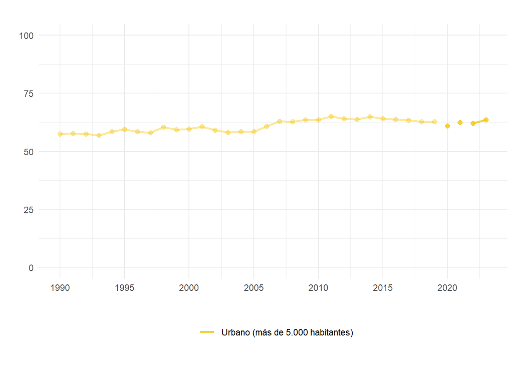

#### Tabla

|  | NOMINDICADOR | PAÍS | UNIDAD_GEOGRÁFICA | ANIO | VALOR |
| --- | --- | --- | --- | --- | --- |
| 1 | TASA DE ACTIVIDAD | URUGUAY | URBANO (MÁS DE 5.000 HABITANTES) | 1990 | 57.5 |
| 2 | TASA DE ACTIVIDAD | URUGUAY | URBANO (MÁS DE 5.000 HABITANTES) | 1991 | 57.7 |
| 3 | TASA DE ACTIVIDAD | URUGUAY | URBANO (MÁS DE 5.000 HABITANTES) | 1992 | 57.5 |
| 4 | TASA DE ACTIVIDAD | URUGUAY | URBANO (MÁS DE 5.000 HABITANTES) | 1993 | 56.9 |
| 5 | TASA DE ACTIVIDAD | URUGUAY | URBANO (MÁS DE 5.000 HABITANTES) | 1994 | 58.4 |
| 6 | TASA DE ACTIVIDAD | URUGUAY | URBANO (MÁS DE 5.000 HABITANTES) | 1995 | 59.4 |
| 7 | TASA DE ACTIVIDAD | URUGUAY | URBANO (MÁS DE 5.000 HABITANTES) | 1996 | 58.5 |
| 8 | TASA DE ACTIVIDAD | URUGUAY | URBANO (MÁS DE 5.000 HABITANTES) | 1997 | 58 |
| 9 | TASA DE ACTIVIDAD | URUGUAY | URBANO (MÁS DE 5.000 HABITANTES) | 1998 | 60.4 |
| 10 | TASA DE ACTIVIDAD | URUGUAY | URBANO (MÁS DE 5.000 HABITANTES) | 1999 | 59.3 |

[output cut: 24 more lines]

#### Ficha Técnica

> **Definición:** Proporción de la población en edad de trabajar (mayores de 14 años) que se encuentran económicamente activos (se encuentran ocupados o buscando activamente empleo).

> **Forma de cálculo:** Cociente entre la población económicamente activa y la población en edad de trabajar.

> **Advertencia:** Desde marzo de 2020 hasta junio de 2021 se interrumpió el relevamiento presencial y se aplicó de manera telefónica un cuestionario restringido con el objetivo de continuar publicando los indicadores de ingresos y mercado de trabajo. En ese período la encuesta pasó a ser de paneles rotativos elegidos al azar a partir de los casos respondentes del año anterior.  
> En julio de 2021 el INE retomó la realización de encuestas presenciales, pero introdujo un cambio metodológico, ya que la ECH pasa a ser una encuesta de panel rotativo con periodicidad mensual compuesta por seis paneles o grupos de rotación, cada uno de los cuales es una muestra representativa de la población. Con esta nueva metodología, cada hogar seleccionado participa durante seis meses de la ECH.  
> Para 2020, este indicador se construye con la encuesta presencial hasta marzo de 2020 y, posteriormente, con la encuesta telefónica panel. Para 2021, este indicador se calcula a partir de la encuesta telefónica del primer semestre de 2021 y el formulario telefónico de modalidad panel del segundo semestre de 2021. En el segundo semestre, el quintil de ingresos y la condición de pobreza del hogar corresponde a los ingresos declarados durante la implantación del panel en la encuesta presencial. A partir del año 2022, el indicador se calcula con base en la encuesta telefónica panel.

#### Código en R

```r
### Estimación de valores 2022 ###

# Para sintaxix de años anteriores consultar:
# https://osf.io/dyzg8/files/osfstorage#

# ~~~~~~~~~~~~~~~~~~~~~~~~~~~~~~~~~~~~~~~~~~~~~~~~~~~~~~~~~~~~~~~~~~~~~~~~~~~ #

### Carga de paquetes ###

# Instalar si es necesario:
#install.packages("rio")
#install.packages("srvyr")
#install.packages("tidyverse")

library(rio)
library(srvyr)
library(tidyverse)


# ~~~~~~~~~~~~~~~~~~~~~~~~~~~~~~~~~~~~~~~~~~~~~~~~~~~~~~~~~~~~~~~~~~~~~~~~~~~ #

### Descarga bases ECH 2022 (INE) de repositorio UMAD-FCS ###

download.file(
  url = "https://osf.io/download/xnzta/",
  destfile = "ECH_men_22.Rdata"
)

# ~~~~~~~~~~~~~~~~~~~~~~~~~~~~~~~~~~~~~~~~~~~~~~~~~~~~~~~~~~~~~~~~~~~~~~~~~~~ #

### Carga de bases ###

bases_men       <- rio::import("Bases/ECH_men_22.csv")

# ~~~~~~~~~~~~~~~~~~~~~~~~~~~~~~~~~~~~~~~~~~~~~~~~~~~~~~~~~~~~~~~~~~~~~~~~~~~ #


## Generación de nuevas variables ###


# Población económicamente activa

bases_men <- bases_men %>% dplyr::mutate(pea = ifelse(POBPCOAC==2 |
                                                        POBPCOAC==3 |
                                                        POBPCOAC==4 |
                                                        POBPCOAC==5, 1, 0))


# ~~~~~~~~~~~~~~~~~~~~~~~~~~~~~~~~~~~~~~~~~~~~~~~~~~~~~~~~~~~~~~~~~~~~~~~~~~~ #

### Información de muestreo ###

base_men_svy <- srvyr::as_survey_design(bases_men,
                                        ids = ID,
                                        weights = w)


# ~~~~~~~~~~~~~~~~~~~~~~~~~~~~~~~~~~~~~~~~~~~~~~~~~~~~~~~~~~~~~~~~~~~~~~~~~~~ #

### Estimación de indicadores ###


###  Tasa de actividad

a_mes <- base_men_svy %>%
  srvyr::filter(e27>=14) %>%
  srvyr::group_by(mes) %>%
  srvyr::summarise(colname = srvyr::survey_mean(pea, na.rm=T))

c_ano <- mean(as.numeric(a_mes$colname))

# ~~~~~~~~~~~~~~~~~~~~~~~~~~~~~~~~~~~~~~~~~~~~~~~~~~~~~~~~~~~~~~~~~~~~~~~~~~~ #
```

Fuente: Unidad de Métodos y Acceso a Datos (UMAD), Facultad de Ciencias Sociales (FCS-UdelaR), a partir de la ECH del Instituto Nacional de Estadística (INE) compatibilizada por el Instituto de Economía (IECON) (2019) y ECH-INE (2020 a 2022)

Nota: La transparencia de colores representa cambios metodológicos en el relevamiento de las ECH. La línea se discontinúa en aquellos años en que ocurre el cambio (ver Ficha Técnica).

##### **Tasa de actividad, según sexo**

##### País Urbano, 1990 - 2023

#### Gráfico

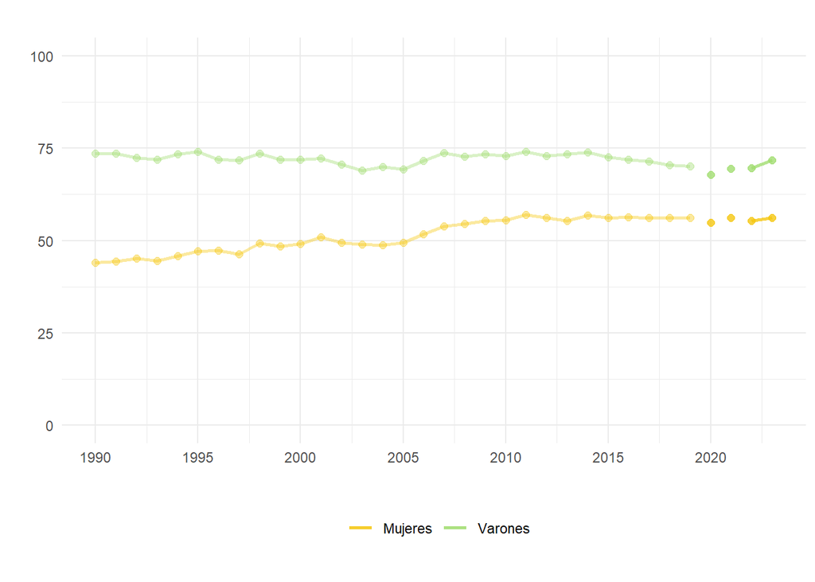

#### Tabla

|  | NOMINDICADOR | PAÍS | UNIDAD_GEOGRÁFICA | SEXO | ANIO | VALOR |
| --- | --- | --- | --- | --- | --- | --- |
| 32 | TASA DE ACTIVIDAD | URUGUAY | URBANO (MÁS DE 5.000 HABITANTES) | MUJERES | 1990 | 44 |
| 33 | TASA DE ACTIVIDAD | URUGUAY | URBANO (MÁS DE 5.000 HABITANTES) | MUJERES | 1991 | 44.3 |
| 34 | TASA DE ACTIVIDAD | URUGUAY | URBANO (MÁS DE 5.000 HABITANTES) | MUJERES | 1992 | 45.1 |
| 35 | TASA DE ACTIVIDAD | URUGUAY | URBANO (MÁS DE 5.000 HABITANTES) | MUJERES | 1993 | 44.5 |
| 36 | TASA DE ACTIVIDAD | URUGUAY | URBANO (MÁS DE 5.000 HABITANTES) | MUJERES | 1994 | 45.8 |
| 37 | TASA DE ACTIVIDAD | URUGUAY | URBANO (MÁS DE 5.000 HABITANTES) | MUJERES | 1995 | 47.1 |
| 38 | TASA DE ACTIVIDAD | URUGUAY | URBANO (MÁS DE 5.000 HABITANTES) | MUJERES | 1996 | 47.3 |
| 39 | TASA DE ACTIVIDAD | URUGUAY | URBANO (MÁS DE 5.000 HABITANTES) | MUJERES | 1997 | 46.3 |
| 40 | TASA DE ACTIVIDAD | URUGUAY | URBANO (MÁS DE 5.000 HABITANTES) | MUJERES | 1998 | 49.3 |
| 41 | TASA DE ACTIVIDAD | URUGUAY | URBANO (MÁS DE 5.000 HABITANTES) | MUJERES | 1999 | 48.5 |

[output cut: 58 more lines]

#### Ficha Técnica

> **Definición:** Proporción de la población en edad de trabajar (mayores de 14 años) que se encuentran económicamente activos (se encuentran ocupados o buscando activamente empleo).

> **Forma de cálculo:** Cociente entre la población económicamente activa y la población en edad de trabajar.

> **Advertencia:** Desde marzo de 2020 hasta junio de 2021 se interrumpió el relevamiento presencial y se aplicó de manera telefónica un cuestionario restringido con el objetivo de continuar publicando los indicadores de ingresos y mercado de trabajo. En ese período la encuesta pasó a ser de paneles rotativos elegidos al azar a partir de los casos respondentes del año anterior.  
> En julio de 2021 el INE retomó la realización de encuestas presenciales, pero introdujo un cambio metodológico, ya que la ECH pasa a ser una encuesta de panel rotativo con periodicidad mensual compuesta por seis paneles o grupos de rotación, cada uno de los cuales es una muestra representativa de la población. Con esta nueva metodología, cada hogar seleccionado participa durante seis meses de la ECH.  
> Para 2020, este indicador se construye con la encuesta presencial hasta marzo de 2020 y, posteriormente, con la encuesta telefónica panel. Para 2021, este indicador se calcula a partir de la encuesta telefónica del primer semestre de 2021 y el formulario telefónico de modalidad panel del segundo semestre de 2021. En el segundo semestre, el quintil de ingresos y la condición de pobreza del hogar corresponde a los ingresos declarados durante la implantación del panel en la encuesta presencial. A partir del año 2022, el indicador se calcula con base en la encuesta telefónica panel.

#### Código en R

```r
### Estimación de valores 2022 ###

# Para sintaxix de años anteriores consultar:
# https://osf.io/dyzg8/files/osfstorage#

# ~~~~~~~~~~~~~~~~~~~~~~~~~~~~~~~~~~~~~~~~~~~~~~~~~~~~~~~~~~~~~~~~~~~~~~~~~~~ #

### Carga de paquetes ###

# Instalar si es necesario:
#install.packages("rio")
#install.packages("srvyr")
#install.packages("tidyverse")

library(rio)
library(srvyr)
library(tidyverse)


# ~~~~~~~~~~~~~~~~~~~~~~~~~~~~~~~~~~~~~~~~~~~~~~~~~~~~~~~~~~~~~~~~~~~~~~~~~~~ #

### Descarga bases ECH 2022 (INE) de repositorio UMAD-FCS ###


download.file(
  url = "https://osf.io/download/xnzta/",
  destfile = "ECH_men_22.Rdata"
)

# ~~~~~~~~~~~~~~~~~~~~~~~~~~~~~~~~~~~~~~~~~~~~~~~~~~~~~~~~~~~~~~~~~~~~~~~~~~~ #

### Carga de bases ###

bases_men       <- rio::import("Bases/ECH_men_22.csv")

# ~~~~~~~~~~~~~~~~~~~~~~~~~~~~~~~~~~~~~~~~~~~~~~~~~~~~~~~~~~~~~~~~~~~~~~~~~~~ #


## Generación de nuevas variables ###


# Población económicamente activa

bases_men <- bases_men %>% dplyr::mutate(pea = ifelse(POBPCOAC==2 |
                                              POBPCOAC==3 |
                                              POBPCOAC==4 |
                                              POBPCOAC==5, 1, 0))

# ~~~~~~~~~~~~~~~~~~~~~~~~~~~~~~~~~~~~~~~~~~~~~~~~~~~~~~~~~~~~~~~~~~~~~~~~~~~ #

### Información de muestreo ###

base_men_svy <- srvyr::as_survey_design(bases_men, ids = ID, weights = w)

# ~~~~~~~~~~~~~~~~~~~~~~~~~~~~~~~~~~~~~~~~~~~~~~~~~~~~~~~~~~~~~~~~~~~~~~~~~~~ #

### Estimación de indicadores ###


###  Tasa de actividad según sexo

a_sexo <- function(x) {
  x <- base_men_svy %>%
    filter(bc_pe2 == x & e27>=14) %>%
    srvyr::group_by(mes) %>%
    srvyr::summarise(colname = srvyr::survey_mean(pea, na.rm=T))
  x <- mean(x$colname)
}

tasa <- numeric()

for(i in 1:2){
  tasa[i] <- a_sexo(x = i)
}

# ~~~~~~~~~~~~~~~~~~~~~~~~~~~~~~~~~~~~~~~~~~~~~~~~~~~~~~~~~~~~~~~~~~~~~~~~~~~ #
```

Fuente: Unidad de Métodos y Acceso a Datos (UMAD), Facultad de Ciencias Sociales (FCS-UdelaR), a partir de la ECH del Instituto Nacional de Estadística (INE) compatibilizada por el Instituto de Economía (IECON) (2019) y ECH-INE (2020 a 2022)

Nota: La transparencia de colores representa cambios metodológicos en el relevamiento de las ECH. La línea se discontinúa en aquellos años en que ocurre el cambio (ver Ficha Técnica).

##### **Tasa de actividad, según tramo de edad**

##### País Urbano, 1990 - 2023

#### Gráfico

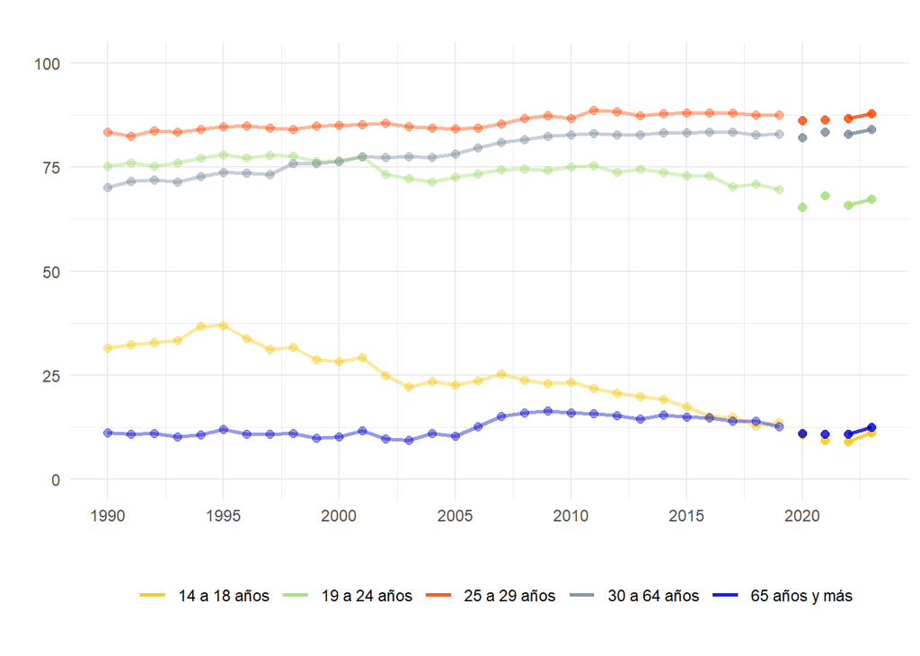

#### Tabla

|  | NOMINDICADOR | PAÍS | UNIDAD_GEOGRÁFICA | TRAMO | ANIO | VALOR |
| --- | --- | --- | --- | --- | --- | --- |
| 1 | TASA DE ACTIVIDAD DE PERSONAS DE 14 A 18 AÑOS | URUGUAY | URBANO (MÁS DE 5.000 HABITANTES) | 14 a 18 años | 1990 | 31.6 |
| 2 | TASA DE ACTIVIDAD DE PERSONAS DE 14 A 18 AÑOS | URUGUAY | URBANO (MÁS DE 5.000 HABITANTES) | 14 a 18 años | 1991 | 32.4 |
| 3 | TASA DE ACTIVIDAD DE PERSONAS DE 14 A 18 AÑOS | URUGUAY | URBANO (MÁS DE 5.000 HABITANTES) | 14 a 18 años | 1992 | 32.8 |
| 4 | TASA DE ACTIVIDAD DE PERSONAS DE 14 A 18 AÑOS | URUGUAY | URBANO (MÁS DE 5.000 HABITANTES) | 14 a 18 años | 1993 | 33.4 |
| 5 | TASA DE ACTIVIDAD DE PERSONAS DE 14 A 18 AÑOS | URUGUAY | URBANO (MÁS DE 5.000 HABITANTES) | 14 a 18 años | 1994 | 36.7 |
| 6 | TASA DE ACTIVIDAD DE PERSONAS DE 14 A 18 AÑOS | URUGUAY | URBANO (MÁS DE 5.000 HABITANTES) | 14 a 18 años | 1995 | 37 |
| 7 | TASA DE ACTIVIDAD DE PERSONAS DE 14 A 18 AÑOS | URUGUAY | URBANO (MÁS DE 5.000 HABITANTES) | 14 a 18 años | 1996 | 33.8 |
| 8 | TASA DE ACTIVIDAD DE PERSONAS DE 14 A 18 AÑOS | URUGUAY | URBANO (MÁS DE 5.000 HABITANTES) | 14 a 18 años | 1997 | 31.2 |
| 9 | TASA DE ACTIVIDAD DE PERSONAS DE 14 A 18 AÑOS | URUGUAY | URBANO (MÁS DE 5.000 HABITANTES) | 14 a 18 años | 1998 | 31.7 |
| 10 | TASA DE ACTIVIDAD DE PERSONAS DE 14 A 18 AÑOS | URUGUAY | URBANO (MÁS DE 5.000 HABITANTES) | 14 a 18 años | 1999 | 28.8 |

[output cut: 160 more lines]

#### Ficha Técnica

> **Definición:** Proporción de la población en edad de trabajar (mayores de 14 años) que se encuentran económicamente activos (se encuentran ocupados o buscando activamente empleo).

> **Forma de cálculo:** Cociente entre la población económicamente activa y la población en edad de trabajar.

> **Advertencia:** Desde marzo de 2020 hasta junio de 2021 se interrumpió el relevamiento presencial y se aplicó de manera telefónica un cuestionario restringido con el objetivo de continuar publicando los indicadores de ingresos y mercado de trabajo. En ese período la encuesta pasó a ser de paneles rotativos elegidos al azar a partir de los casos respondentes del año anterior.  
> En julio de 2021 el INE retomó la realización de encuestas presenciales, pero introdujo un cambio metodológico, ya que la ECH pasa a ser una encuesta de panel rotativo con periodicidad mensual compuesta por seis paneles o grupos de rotación, cada uno de los cuales es una muestra representativa de la población. Con esta nueva metodología, cada hogar seleccionado participa durante seis meses de la ECH.  
> Para 2020, este indicador se construye con la encuesta presencial hasta marzo de 2020 y, posteriormente, con la encuesta telefónica panel. Para 2021, este indicador se calcula a partir de la encuesta telefónica del primer semestre de 2021 y el formulario telefónico de modalidad panel del segundo semestre de 2021. En el segundo semestre, el quintil de ingresos y la condición de pobreza del hogar corresponde a los ingresos declarados durante la implantación del panel en la encuesta presencial. A partir del año 2022, el indicador se calcula con base en la encuesta telefónica panel.

#### Código en R

```r
### Estimación de valores 2022 ###

# Para sintaxix de años anteriores consultar:
# https://osf.io/dyzg8/files/osfstorage#

# ~~~~~~~~~~~~~~~~~~~~~~~~~~~~~~~~~~~~~~~~~~~~~~~~~~~~~~~~~~~~~~~~~~~~~~~~~~~ #

### Carga de paquetes ###

# Instalar si es necesario:
#install.packages("rio")
#install.packages("srvyr")
#install.packages("tidyverse")

library(rio)
library(srvyr)
library(tidyverse)


# ~~~~~~~~~~~~~~~~~~~~~~~~~~~~~~~~~~~~~~~~~~~~~~~~~~~~~~~~~~~~~~~~~~~~~~~~~~~ #

### Descarga bases ECH 2022 (INE) de repositorio UMAD-FCS ###

download.file(
  url = "https://osf.io/download/xnzta/",
  destfile = "ECH_men_22.Rdata"
)

# ~~~~~~~~~~~~~~~~~~~~~~~~~~~~~~~~~~~~~~~~~~~~~~~~~~~~~~~~~~~~~~~~~~~~~~~~~~~ #

### Carga de bases ###

bases_men       <- rio::import("Bases/ECH_men_22.csv")

# ~~~~~~~~~~~~~~~~~~~~~~~~~~~~~~~~~~~~~~~~~~~~~~~~~~~~~~~~~~~~~~~~~~~~~~~~~~~ #


## Generación de nuevas variables ###


# Población económicamente activa

bases_men <- bases_men %>% dplyr::mutate(pea = ifelse(POBPCOAC==2 |
                                              POBPCOAC==3 |
                                              POBPCOAC==4 |
                                              POBPCOAC==5, 1, 0))

bases_men <- bases_men %>% dplyr::mutate(tramo_edad =
                                          case_when(e27 >= 14 & e27 <= 18 ~  1,
                                                    e27 >= 19 & e27 <= 24 ~  2,
                                                    e27 >= 25 & e27 <= 29 ~  3,
                                                    e27 >= 30 & e27 <= 64 ~  4,
                                                    e27 >= 65             ~  5))

# ~~~~~~~~~~~~~~~~~~~~~~~~~~~~~~~~~~~~~~~~~~~~~~~~~~~~~~~~~~~~~~~~~~~~~~~~~~~ #

### Información de muestreo ###

base_men_svy <- srvyr::as_survey_design(bases_men, ids = ID, weights = w)

# ~~~~~~~~~~~~~~~~~~~~~~~~~~~~~~~~~~~~~~~~~~~~~~~~~~~~~~~~~~~~~~~~~~~~~~~~~~~ #

### Estimación de indicadores ###


###  Tasa de actividad según tramo de edad

a_edad <- function(x) {
  x <- base_men_svy %>%
    filter(tramo_edad == x & e27>=14 & (region_4 == 1 | region_4 == 2)) %>%
    srvyr::group_by(mes) %>%
    srvyr::summarise(colname = srvyr::survey_mean(pea, na.rm=T))
  x <- mean(x$colname)
}

a_e_edad <- numeric()

for(i in 1:5){
  a_e_edad[i] <- a_edad(x = i)
}



# ~~~~~~~~~~~~~~~~~~~~~~~~~~~~~~~~~~~~~~~~~~~~~~~~~~~~~~~~~~~~~~~~~~~~~~~~~~~ #
```

Fuente: Unidad de Métodos y Acceso a Datos (UMAD), Facultad de Ciencias Sociales (FCS-UdelaR), a partir de la ECH del Instituto Nacional de Estadística (INE) compatibilizada por el Instituto de Economía (IECON) (2019) y ECH-INE (2020 a 2022)

Nota: La transparencia de colores representa cambios metodológicos en el relevamiento de las ECH. La línea se discontinúa en aquellos años en que ocurre el cambio (ver Ficha Técnica).

## **Empleo**

La tasa de empleo da cuenta de la proporción de personas ocupadas sobre el total de personas en edad de trabajar.

Las personas ocupadas son todas aquellas personas en edad de trabajar que, durante la semana anterior a la aplicación de la encuesta, se dedicaban a alguna actividad para producir bienes o prestar servicios a cambio de remuneración o beneficios, ya sea que estuvieran «trabajando» en un puesto de trabajo por lo menos una hora, o «sin trabajar» debido a una ausencia temporal del puesto de trabajo o debido a disposiciones sobre el ordenamiento del tiempo de trabajo (como trabajo en turnos, horarios flexibles y licencias compensatorias por horas extraordinarias).

Considerando las últimas tres décadas, se observa que la tasa de empleo permanece relativamente estable entre 1990 y 1997, disminuye entre 1998 y 2003 y crece de forma significativa entre 2004 y 2014, año a partir del cual el crecimiento se estanca y decrece levemente.

Al igual que para la tasa de actividad, la brecha según sexo de la tasa de empleo disminuye sustantcialmente, pasando de 29,4 puntos porcentuales en 1990 a 15,1 en 2023.

##### **Tasa de empleo**

##### País Urbano, 1990 - 2023

#### Gráfico

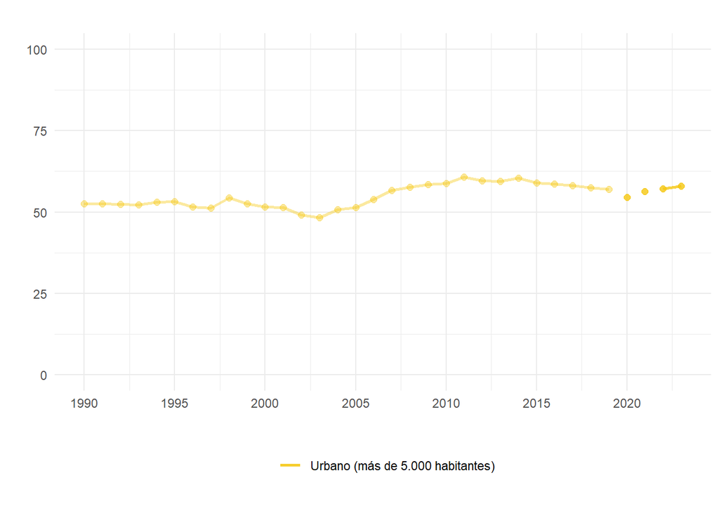

#### Tabla

|  | NOMINDICADOR | PAÍS | UNIDAD_GEOGRÁFICA | ANIO | VALOR |
| --- | --- | --- | --- | --- | --- |
| 1 | TASA DE EMPLEO | URUGUAY | URBANO (MÁS DE 5.000 HABITANTES) | 1990 | 52.5 |
| 2 | TASA DE EMPLEO | URUGUAY | URBANO (MÁS DE 5.000 HABITANTES) | 1991 | 52.6 |
| 3 | TASA DE EMPLEO | URUGUAY | URBANO (MÁS DE 5.000 HABITANTES) | 1992 | 52.4 |
| 4 | TASA DE EMPLEO | URUGUAY | URBANO (MÁS DE 5.000 HABITANTES) | 1993 | 52.2 |
| 5 | TASA DE EMPLEO | URUGUAY | URBANO (MÁS DE 5.000 HABITANTES) | 1994 | 53 |
| 6 | TASA DE EMPLEO | URUGUAY | URBANO (MÁS DE 5.000 HABITANTES) | 1995 | 53.2 |
| 7 | TASA DE EMPLEO | URUGUAY | URBANO (MÁS DE 5.000 HABITANTES) | 1996 | 51.5 |
| 8 | TASA DE EMPLEO | URUGUAY | URBANO (MÁS DE 5.000 HABITANTES) | 1997 | 51.3 |
| 9 | TASA DE EMPLEO | URUGUAY | URBANO (MÁS DE 5.000 HABITANTES) | 1998 | 54.3 |
| 10 | TASA DE EMPLEO | URUGUAY | URBANO (MÁS DE 5.000 HABITANTES) | 1999 | 52.6 |

[output cut: 24 more lines]

#### Ficha Técnica

> **Definición:** Proporción de la población en edad de trabajar (mayores de 14 años) que se encuentra ocupada.

> **Forma de cálculo:** Cociente entre la población ocupada y la población en edad de trabajar

> **Advertencia:** Desde marzo de 2020 hasta junio de 2021 se interrumpió el relevamiento presencial y se aplicó de manera telefónica un cuestionario restringido con el objetivo de continuar publicando los indicadores de ingresos y mercado de trabajo. En ese período la encuesta pasó a ser de paneles rotativos elegidos al azar a partir de los casos respondentes del año anterior.  
> En julio de 2021 el INE retomó la realización de encuestas presenciales, pero introdujo un cambio metodológico, ya que la ECH pasa a ser una encuesta de panel rotativo con periodicidad mensual compuesta por seis paneles o grupos de rotación, cada uno de los cuales es una muestra representativa de la población. Con esta nueva metodología, cada hogar seleccionado participa durante seis meses de la ECH.  
> Para 2020, este indicador se construye con la encuesta presencial hasta marzo de 2020 y, posteriormente, con la encuesta telefónica panel. Para 2021, este indicador se calcula a partir de la encuesta telefónica del primer semestre de 2021 y el formulario telefónico de modalidad panel del segundo semestre de 2021. En el segundo semestre, el quintil de ingresos y la condición de pobreza del hogar corresponde a los ingresos declarados durante la implantación del panel en la encuesta presencial. A partir del año 2022, el indicador se calcula con base en la encuesta telefónica panel.

#### Código en R

```r
### Estimación de valores 2022 ###

# Para sintaxix de años anteriores consultar:
# https://osf.io/dyzg8/files/osfstorage#

# ~~~~~~~~~~~~~~~~~~~~~~~~~~~~~~~~~~~~~~~~~~~~~~~~~~~~~~~~~~~~~~~~~~~~~~~~~~~ #

### Carga de paquetes ###

# Instalar si es necesario:
#install.packages("rio")
#install.packages("srvyr")
#install.packages("tidyverse")

library(rio)
library(srvyr)
library(tidyverse)


# ~~~~~~~~~~~~~~~~~~~~~~~~~~~~~~~~~~~~~~~~~~~~~~~~~~~~~~~~~~~~~~~~~~~~~~~~~~~ #

### Descarga bases ECH 2022 (INE) de repositorio UMAD-FCS ###

download.file(
  url = "https://osf.io/download/xnzta/",
  destfile = "ECH_men_22.Rdata"
)

# ~~~~~~~~~~~~~~~~~~~~~~~~~~~~~~~~~~~~~~~~~~~~~~~~~~~~~~~~~~~~~~~~~~~~~~~~~~~ #

### Carga de bases ###

bases_men       <- rio::import("Bases/ECH_men_22.csv")

# ~~~~~~~~~~~~~~~~~~~~~~~~~~~~~~~~~~~~~~~~~~~~~~~~~~~~~~~~~~~~~~~~~~~~~~~~~~~ #


## Generación de nuevas variables ###

# Ocupados

bases_men <- bases_men %>% dplyr::mutate(ocup = ifelse(POBPCOAC==2, 1, 0))


~~~~~~~~~~~~~~~~~~~~~~~~~~~~~~~~~~~~~~~~~~~~~~~~~~~~~~~~~~~~~~~~~~~~~~~~~~~ #

### Información de muestreo ###

base_men_svy <- srvyr::as_survey_design(bases_men,
                                        ids = ID,
                                        weights = w)

# ~~~~~~~~~~~~~~~~~~~~~~~~~~~~~~~~~~~~~~~~~~~~~~~~~~~~~~~~~~~~~~~~~~~~~~~~~~~ #

### Estimación de indicadores ###


###  Tasa de empleo

a_mes <- base_men_svy %>%
  srvyr::filter(e27>=14 & (region_4 == 1 | region_4 == 2)) %>%
  srvyr::group_by(mes) %>%
  srvyr::summarise(colname = srvyr::survey_mean(ocup, na.rm=T))

c_ano <- mean(as.numeric(a_mes$colname))


# ~~~~~~~~~~~~~~~~~~~~~~~~~~~~~~~~~~~~~~~~~~~~~~~~~~~~~~~~~~~~~~~~~~~~~~~~~~~ #
```

Fuente: Unidad de Métodos y Acceso a Datos (UMAD), Facultad de Ciencias Sociales (FCS-UdelaR), a partir de la ECH del Instituto Nacional de Estadística (INE) compatibilizada por el Instituto de Economía (IECON) (2019) y ECH-INE (2020 a 2022)

Nota: La transparencia de colores representa cambios metodológicos en el relevamiento de las ECH. La línea se discontinúa en aquellos años en que ocurre el cambio (ver Ficha Técnica).

##### **Tasa de empleo, según sexo**

##### País Urbano, 1990 - 2023

#### Gráfico

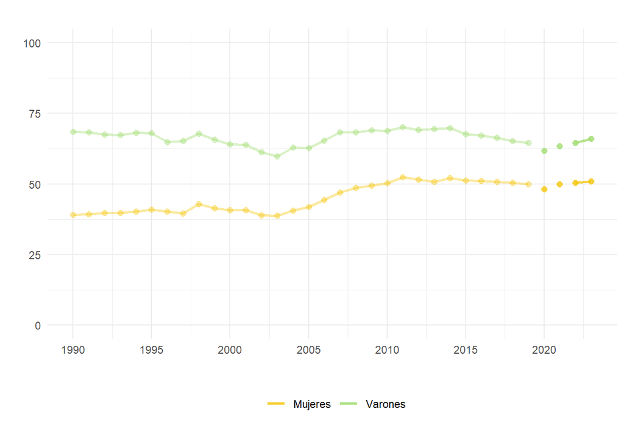

#### Tabla

|  | NOMINDICADOR | PAÍS | UNIDAD_GEOGRÁFICA | SEXO | ANIO | VALOR |
| --- | --- | --- | --- | --- | --- | --- |
| 32 | TASA DE EMPLEO | URUGUAY | URBANO (MÁS DE 5.000 HABITANTES) | MUJERES | 1990 | 39.1 |
| 33 | TASA DE EMPLEO | URUGUAY | URBANO (MÁS DE 5.000 HABITANTES) | MUJERES | 1991 | 39.2 |
| 34 | TASA DE EMPLEO | URUGUAY | URBANO (MÁS DE 5.000 HABITANTES) | MUJERES | 1992 | 39.7 |
| 35 | TASA DE EMPLEO | URUGUAY | URBANO (MÁS DE 5.000 HABITANTES) | MUJERES | 1993 | 39.7 |
| 36 | TASA DE EMPLEO | URUGUAY | URBANO (MÁS DE 5.000 HABITANTES) | MUJERES | 1994 | 40.2 |
| 37 | TASA DE EMPLEO | URUGUAY | URBANO (MÁS DE 5.000 HABITANTES) | MUJERES | 1995 | 40.9 |
| 38 | TASA DE EMPLEO | URUGUAY | URBANO (MÁS DE 5.000 HABITANTES) | MUJERES | 1996 | 40.3 |
| 39 | TASA DE EMPLEO | URUGUAY | URBANO (MÁS DE 5.000 HABITANTES) | MUJERES | 1997 | 39.5 |
| 40 | TASA DE EMPLEO | URUGUAY | URBANO (MÁS DE 5.000 HABITANTES) | MUJERES | 1998 | 42.8 |
| 41 | TASA DE EMPLEO | URUGUAY | URBANO (MÁS DE 5.000 HABITANTES) | MUJERES | 1999 | 41.4 |

[output cut: 58 more lines]

#### Ficha Técnica

> **Definición:** Proporción de la población en edad de trabajar (mayores de 14 años) que se encuentra ocupada.

> **Forma de cálculo:** Cociente entre la población ocupada y la población en edad de trabajar

> **Advertencia:** Desde marzo de 2020 hasta junio de 2021 se interrumpió el relevamiento presencial y se aplicó de manera telefónica un cuestionario restringido con el objetivo de continuar publicando los indicadores de ingresos y mercado de trabajo. En ese período la encuesta pasó a ser de paneles rotativos elegidos al azar a partir de los casos respondentes del año anterior.  
> En julio de 2021 el INE retomó la realización de encuestas presenciales, pero introdujo un cambio metodológico, ya que la ECH pasa a ser una encuesta de panel rotativo con periodicidad mensual compuesta por seis paneles o grupos de rotación, cada uno de los cuales es una muestra representativa de la población. Con esta nueva metodología, cada hogar seleccionado participa durante seis meses de la ECH.  
> Para 2020, este indicador se construye con la encuesta presencial hasta marzo de 2020 y, posteriormente, con la encuesta telefónica panel. Para 2021, este indicador se calcula a partir de la encuesta telefónica del primer semestre de 2021 y el formulario telefónico de modalidad panel del segundo semestre de 2021. En el segundo semestre, el quintil de ingresos y la condición de pobreza del hogar corresponde a los ingresos declarados durante la implantación del panel en la encuesta presencial. A partir del año 2022, el indicador se calcula con base en la encuesta telefónica panel.

#### Código en R

```r
### Estimación de valores 2022 ###

# Para sintaxix de años anteriores consultar:
# https://osf.io/dyzg8/files/osfstorage#

# ~~~~~~~~~~~~~~~~~~~~~~~~~~~~~~~~~~~~~~~~~~~~~~~~~~~~~~~~~~~~~~~~~~~~~~~~~~~ #

### Carga de paquetes ###

# Instalar si es necesario:
#install.packages("rio")
#install.packages("srvyr")
#install.packages("tidyverse")

library(rio)
library(srvyr)
library(tidyverse)


# ~~~~~~~~~~~~~~~~~~~~~~~~~~~~~~~~~~~~~~~~~~~~~~~~~~~~~~~~~~~~~~~~~~~~~~~~~~~ #

### Descarga bases ECH 2022 (INE) de repositorio UMAD-FCS ###

download.file(
  url = "https://osf.io/download/xnzta/",
  destfile = "ECH_men_22.Rdata"
)

# ~~~~~~~~~~~~~~~~~~~~~~~~~~~~~~~~~~~~~~~~~~~~~~~~~~~~~~~~~~~~~~~~~~~~~~~~~~~ #

### Carga de bases ###

bases_men       <- rio::import("Bases/ECH_men_22.csv")

# ~~~~~~~~~~~~~~~~~~~~~~~~~~~~~~~~~~~~~~~~~~~~~~~~~~~~~~~~~~~~~~~~~~~~~~~~~~~ #


## Generación de nuevas variables ###


# Ocupados

bases_men <- bases_men %>% dplyr::mutate(ocup = ifelse(POBPCOAC==2, 1, 0))


# ~~~~~~~~~~~~~~~~~~~~~~~~~~~~~~~~~~~~~~~~~~~~~~~~~~~~~~~~~~~~~~~~~~~~~~~~~~~ #

### Información de muestreo ###

base_men_svy <- srvyr::as_survey_design(bases_men, ids = ID, weights = w)

# ~~~~~~~~~~~~~~~~~~~~~~~~~~~~~~~~~~~~~~~~~~~~~~~~~~~~~~~~~~~~~~~~~~~~~~~~~~~ #

### Estimación de indicadores ###


###  Tasa de empleo según sexo

a_sexo <- function(x) {
  x <- base_men_svy %>%
    filter(bc_pe2 == x & E27>=14 & (region_4 == 1 | region_4 == 2)) %>%
    srvyr::group_by(mes) %>%
    srvyr::summarise(colname = srvyr::survey_mean(ocup, na.rm=T))
  x <- mean(x$colname)
}

a_e_sexo <- numeric()

for(i in 1:2){
  a_e_sexo[i] <- a_sexo(x = i)
}



# ~~~~~~~~~~~~~~~~~~~~~~~~~~~~~~~~~~~~~~~~~~~~~~~~~~~~~~~~~~~~~~~~~~~~~~~~~~~ #
```

Fuente: Unidad de Métodos y Acceso a Datos (UMAD), Facultad de Ciencias Sociales (FCS-UdelaR), a partir de la ECH del Instituto Nacional de Estadística (INE) compatibilizada por el Instituto de Economía (IECON) (2019) y ECH-INE (2020 a 2022)

Nota: La transparencia de colores representa cambios metodológicos en el relevamiento de las ECH. La línea se discontinúa en aquellos años en que ocurre el cambio (ver Ficha Técnica).

## **Desempleo**

##### **Tasa de desempleo**

##### País Urbano, 1990 - 2023

#### Gráfico

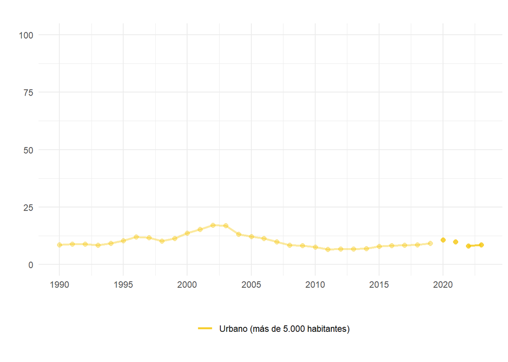

#### Tabla

|  | NOMINDICADOR | PAÍS | UNIDAD_GEOGRÁFICA | ANIO | VALOR |
| --- | --- | --- | --- | --- | --- |
| 1 | TASA DE DESEMPLEO | URUGUAY | URBANO (MÁS DE 5.000 HABITANTES) | 1990 | 8.6 |
| 2 | TASA DE DESEMPLEO | URUGUAY | URBANO (MÁS DE 5.000 HABITANTES) | 1991 | 8.9 |
| 3 | TASA DE DESEMPLEO | URUGUAY | URBANO (MÁS DE 5.000 HABITANTES) | 1992 | 8.9 |
| 4 | TASA DE DESEMPLEO | URUGUAY | URBANO (MÁS DE 5.000 HABITANTES) | 1993 | 8.3 |
| 5 | TASA DE DESEMPLEO | URUGUAY | URBANO (MÁS DE 5.000 HABITANTES) | 1994 | 9.2 |
| 6 | TASA DE DESEMPLEO | URUGUAY | URBANO (MÁS DE 5.000 HABITANTES) | 1995 | 10.4 |
| 7 | TASA DE DESEMPLEO | URUGUAY | URBANO (MÁS DE 5.000 HABITANTES) | 1996 | 12 |
| 8 | TASA DE DESEMPLEO | URUGUAY | URBANO (MÁS DE 5.000 HABITANTES) | 1997 | 11.6 |
| 9 | TASA DE DESEMPLEO | URUGUAY | URBANO (MÁS DE 5.000 HABITANTES) | 1998 | 10.1 |
| 10 | TASA DE DESEMPLEO | URUGUAY | URBANO (MÁS DE 5.000 HABITANTES) | 1999 | 11.3 |

[output cut: 24 more lines]

#### Ficha Técnica

> **Definición:** Proporción de personas económicamente activas que buscan empleo pero no acceden a un puesto de trabajo.

> **Forma de cálculo:** Cociente entre la población desempleada y la población económicamente activa

> **Advertencia:** Desde marzo de 2020 hasta junio de 2021 se interrumpió el relevamiento presencial y se aplicó de manera telefónica un cuestionario restringido con el objetivo de continuar publicando los indicadores de ingresos y mercado de trabajo. En ese período la encuesta pasó a ser de paneles rotativos elegidos al azar a partir de los casos respondentes del año anterior.  
> En julio de 2021 el INE retomó la realización de encuestas presenciales, pero introdujo un cambio metodológico, ya que la ECH pasa a ser una encuesta de panel rotativo con periodicidad mensual compuesta por seis paneles o grupos de rotación, cada uno de los cuales es una muestra representativa de la población. Con esta nueva metodología, cada hogar seleccionado participa durante seis meses de la ECH.  
> Para 2020, este indicador se construye con la encuesta presencial hasta marzo de 2020 y, posteriormente, con la encuesta telefónica panel. Para 2021, este indicador se calcula a partir de la encuesta telefónica del primer semestre de 2021 y el formulario telefónico de modalidad panel del segundo semestre de 2021. En el segundo semestre, el quintil de ingresos y la condición de pobreza del hogar corresponde a los ingresos declarados durante la implantación del panel en la encuesta presencial. A partir del año 2022, el indicador se calcula con base en la encuesta telefónica panel.

#### Código en R

```r
### Estimación de valores 2022 ###

# Para sintaxix de años anteriores consultar:
# https://osf.io/dyzg8/files/osfstorage#

# ~~~~~~~~~~~~~~~~~~~~~~~~~~~~~~~~~~~~~~~~~~~~~~~~~~~~~~~~~~~~~~~~~~~~~~~~~~~ #

### Carga de paquetes ###

# Instalar si es necesario:
#install.packages("rio")
#install.packages("srvyr")
#install.packages("tidyverse")

library(rio)
library(srvyr)
library(tidyverse)


# ~~~~~~~~~~~~~~~~~~~~~~~~~~~~~~~~~~~~~~~~~~~~~~~~~~~~~~~~~~~~~~~~~~~~~~~~~~~ #

### Descarga bases ECH 2022 (INE) de repositorio UMAD-FCS ###

download.file(
  url = "https://osf.io/download/xnzta/",
  destfile = "ECH_men_22.Rdata"
)

# ~~~~~~~~~~~~~~~~~~~~~~~~~~~~~~~~~~~~~~~~~~~~~~~~~~~~~~~~~~~~~~~~~~~~~~~~~~~ #

### Carga de bases ###

base            <- rio::import("Bases/Base anual 2022.csv")

# ~~~~~~~~~~~~~~~~~~~~~~~~~~~~~~~~~~~~~~~~~~~~~~~~~~~~~~~~~~~~~~~~~~~~~~~~~~~ #


## Generación de nuevas variables ###


# Población económicamente activa

bases_men <- bases_men %>% dplyr::mutate(pea = ifelse(POBPCOAC==2 |
                                                        POBPCOAC==3 |
                                                        POBPCOAC==4 |
                                                        POBPCOAC==5, 1, 0)

# Desempleados

bases_men <- bases_men %>% dplyr::mutate(desocup = ifelse(POBPCOAC==3 |
                                                            POBPCOAC==4 |
                                                            POBPCOAC==5, 1, 0))


# ~~~~~~~~~~~~~~~~~~~~~~~~~~~~~~~~~~~~~~~~~~~~~~~~~~~~~~~~~~~~~~~~~~~~~~~~~~~ #

### Información de muestreo ###

base_men_svy <- srvyr::as_survey_design(bases_men, ids = ID, weights = w)


# ~~~~~~~~~~~~~~~~~~~~~~~~~~~~~~~~~~~~~~~~~~~~~~~~~~~~~~~~~~~~~~~~~~~~~~~~~~~ #

### Estimación de indicadores ###


###  Tasa de desempleo

a_mes <- base_men_svy %>%
  srvyr::filter(pea == 1 & (region_4 == 1 | region_4 == 2)) %>%
  srvyr::group_by(mes) %>%
  srvyr::summarise(colname = srvyr::survey_mean(desocup, na.rm=T))

c_ano <- mean(as.numeric(a_mes$colname))


# ~~~~~~~~~~~~~~~~~~~~~~~~~~~~~~~~~~~~~~~~~~~~~~~~~~~~~~~~~~~~~~~~~~~~~~~~~~~ #
```

Fuente: Unidad de Métodos y Acceso a Datos (UMAD), Facultad de Ciencias Sociales (FCS-UdelaR), a partir de la ECH del Instituto Nacional de Estadística (INE) compatibilizada por el Instituto de Economía (IECON) (2019) y ECH-INE (2020 a 2022)

Nota: La transparencia de colores representa cambios metodológicos en el relevamiento de las ECH. La línea se discontinúa en aquellos años en que ocurre el cambio (ver Ficha Técnica).

##### **Tasa de desempleo, según sexo**

##### País Urbano, 1990 - 2023

#### Gráfico

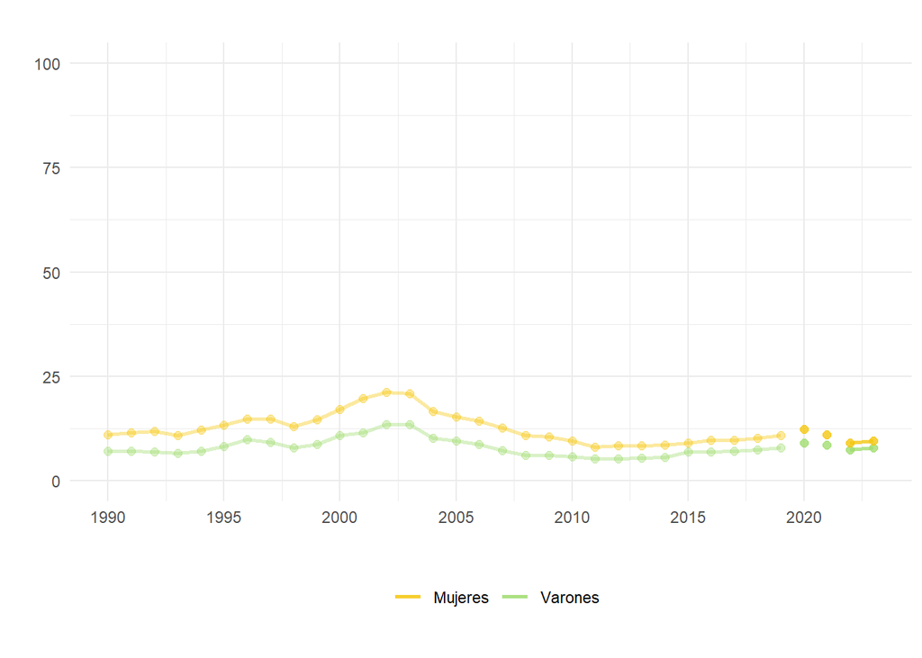

#### Tabla

|  | NOMINDICADOR | PAÍS | UNIDAD_GEOGRÁFICA | SEXO | ANIO | VALOR |
| --- | --- | --- | --- | --- | --- | --- |
| 32 | TASA DE DESEMPLEO | URUGUAY | URBANO (MÁS DE 5.000 HABITANTES) | MUJERES | 1990 | 11 |
| 33 | TASA DE DESEMPLEO | URUGUAY | URBANO (MÁS DE 5.000 HABITANTES) | MUJERES | 1991 | 11.4 |
| 34 | TASA DE DESEMPLEO | URUGUAY | URBANO (MÁS DE 5.000 HABITANTES) | MUJERES | 1992 | 11.8 |
| 35 | TASA DE DESEMPLEO | URUGUAY | URBANO (MÁS DE 5.000 HABITANTES) | MUJERES | 1993 | 10.8 |
| 36 | TASA DE DESEMPLEO | URUGUAY | URBANO (MÁS DE 5.000 HABITANTES) | MUJERES | 1994 | 12.1 |
| 37 | TASA DE DESEMPLEO | URUGUAY | URBANO (MÁS DE 5.000 HABITANTES) | MUJERES | 1995 | 13.3 |
| 38 | TASA DE DESEMPLEO | URUGUAY | URBANO (MÁS DE 5.000 HABITANTES) | MUJERES | 1996 | 14.7 |
| 39 | TASA DE DESEMPLEO | URUGUAY | URBANO (MÁS DE 5.000 HABITANTES) | MUJERES | 1997 | 14.8 |
| 40 | TASA DE DESEMPLEO | URUGUAY | URBANO (MÁS DE 5.000 HABITANTES) | MUJERES | 1998 | 13 |
| 41 | TASA DE DESEMPLEO | URUGUAY | URBANO (MÁS DE 5.000 HABITANTES) | MUJERES | 1999 | 14.6 |

[output cut: 58 more lines]

#### Ficha Técnica

> **Definición:** Proporción de personas económicamente activas que buscan empleo pero no acceden a un puesto de trabajo.

> **Forma de cálculo:** Cociente entre la población desempleada y la población económicamente activa

> **Advertencia:** Desde marzo de 2020 hasta junio de 2021 se interrumpió el relevamiento presencial y se aplicó de manera telefónica un cuestionario restringido con el objetivo de continuar publicando los indicadores de ingresos y mercado de trabajo. En ese período la encuesta pasó a ser de paneles rotativos elegidos al azar a partir de los casos respondentes del año anterior.  
> En julio de 2021 el INE retomó la realización de encuestas presenciales, pero introdujo un cambio metodológico, ya que la ECH pasa a ser una encuesta de panel rotativo con periodicidad mensual compuesta por seis paneles o grupos de rotación, cada uno de los cuales es una muestra representativa de la población. Con esta nueva metodología, cada hogar seleccionado participa durante seis meses de la ECH.  
> Para 2020, este indicador se construye con la encuesta presencial hasta marzo de 2020 y, posteriormente, con la encuesta telefónica panel. Para 2021, este indicador se calcula a partir de la encuesta telefónica del primer semestre de 2021 y el formulario telefónico de modalidad panel del segundo semestre de 2021. En el segundo semestre, el quintil de ingresos y la condición de pobreza del hogar corresponde a los ingresos declarados durante la implantación del panel en la encuesta presencial. A partir del año 2022, el indicador se calcula con base en la encuesta telefónica panel.

#### Código en R

```r
### Estimación de valores 2022 ###

# Para sintaxix de años anteriores consultar:
# https://osf.io/dyzg8/files/osfstorage#

# ~~~~~~~~~~~~~~~~~~~~~~~~~~~~~~~~~~~~~~~~~~~~~~~~~~~~~~~~~~~~~~~~~~~~~~~~~~~ #

### Carga de paquetes ###

# Instalar si es necesario:
#install.packages("rio")
#install.packages("srvyr")
#install.packages("tidyverse")

library(rio)
library(srvyr)
library(tidyverse)


# ~~~~~~~~~~~~~~~~~~~~~~~~~~~~~~~~~~~~~~~~~~~~~~~~~~~~~~~~~~~~~~~~~~~~~~~~~~~ #

### Descarga bases ECH 2022 (INE) de repositorio UMAD-FCS ###

download.file(
  url = "https://osf.io/download/xnzta/",
  destfile = "ECH_men_22.Rdata"
)

# ~~~~~~~~~~~~~~~~~~~~~~~~~~~~~~~~~~~~~~~~~~~~~~~~~~~~~~~~~~~~~~~~~~~~~~~~~~~ #

### Carga de bases ###

bases_men       <- rio::import("Bases/ECH_men_22.csv")

# ~~~~~~~~~~~~~~~~~~~~~~~~~~~~~~~~~~~~~~~~~~~~~~~~~~~~~~~~~~~~~~~~~~~~~~~~~~~ #


## Generación de nuevas variables ###


# Población económicamente activa

bases_men <- bases_men %>% dplyr::mutate(pea = ifelse(POBPCOAC==2 |
                                                        POBPCOAC==3 |
                                                        POBPCOAC==4 |
                                                        POBPCOAC==5, 1, 0))

# Desempleados

bases_men <- bases_men %>% dplyr::mutate(desocup = ifelse(POBPCOAC==3 |
                                                            POBPCOAC==4 |
                                                            POBPCOAC==5, 1, 0))


# ~~~~~~~~~~~~~~~~~~~~~~~~~~~~~~~~~~~~~~~~~~~~~~~~~~~~~~~~~~~~~~~~~~~~~~~~~~~ #

### Información de muestreo ###

base_men_svy <- srvyr::as_survey_design(bases_men,
                                        ids = ID,
                                        weights = w)

# ~~~~~~~~~~~~~~~~~~~~~~~~~~~~~~~~~~~~~~~~~~~~~~~~~~~~~~~~~~~~~~~~~~~~~~~~~~~ #

### Estimación de indicadores ###


###  Tasa de desempleo según sexo

a_sexo <- function(x) {
  x <- base_men_svy %>%
    filter(bc_pe2 == x & pea == 1 & (region_4 == 1 | region_4 == 2)) %>%
    srvyr::group_by(mes) %>%
    srvyr::summarise(colname = srvyr::survey_mean(desocup, na.rm=T))
  x <- mean(x$colname)
}

a_e_sexo <- numeric()

for(i in 1:2){
  a_e_sexo[i] <- a_sexo(x = i)
}


# ~~~~~~~~~~~~~~~~~~~~~~~~~~~~~~~~~~~~~~~~~~~~~~~~~~~~~~~~~~~~~~~~~~~~~~~~~~~ #
```

Fuente: Unidad de Métodos y Acceso a Datos (UMAD), Facultad de Ciencias Sociales (FCS-UdelaR), a partir de la ECH del Instituto Nacional de Estadística (INE) compatibilizada por el Instituto de Economía (IECON) (2019) y ECH-INE (2020 a 2022)

Nota: La transparencia de colores representa cambios metodológicos en el relevamiento de las ECH. La línea se discontinúa en aquellos años en que ocurre el cambio (ver Ficha Técnica).

## **Calidad del empleo**

La tasa de subempleo representa la cantidad de personas ocupadas que trabajan menos de 40 horas semanales, que querrían y pueden trabajar más horas a la semana. Este indicador presenta un leve aumento entre 1993 y 1996 y un aumento importante desde 1998 hasta el año 2003. Desde el año 2004 decrece significativamente hasta el año 2014.

Este indicador es mayor para las mujeres que para los varones en todo el período y presenta una tendencia similar para ambos. Si bien la brecha en la tasa de subempleo de varones y mujeres disminuye de forma continua desde finales de los 90, en 2016 tiene una caída sustancial, permaneciendo en el entorno de 10%.

##### **Tasa de subempleo**

##### País Urbano, 1991 - 2023

#### Gráfico

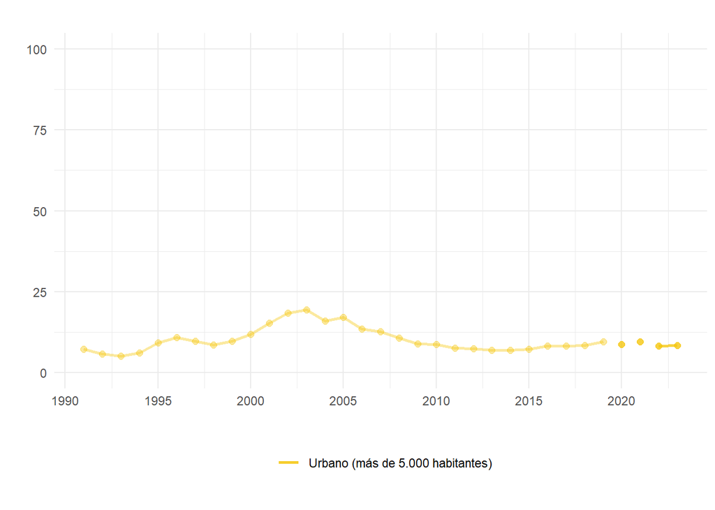

#### Tabla

|  | NOMINDICADOR | PAÍS | UNIDAD_GEOGRÁFICA | ANIO | VALOR |
| --- | --- | --- | --- | --- | --- |
| 1 | TASA DE SUBEMPLEO | URUGUAY | URBANO (MÁS DE 5.000 HABITANTES) | 1991 | 7.2 |
| 2 | TASA DE SUBEMPLEO | URUGUAY | URBANO (MÁS DE 5.000 HABITANTES) | 1992 | 5.8 |
| 3 | TASA DE SUBEMPLEO | URUGUAY | URBANO (MÁS DE 5.000 HABITANTES) | 1993 | 5 |
| 4 | TASA DE SUBEMPLEO | URUGUAY | URBANO (MÁS DE 5.000 HABITANTES) | 1994 | 6.1 |
| 5 | TASA DE SUBEMPLEO | URUGUAY | URBANO (MÁS DE 5.000 HABITANTES) | 1995 | 9.2 |
| 6 | TASA DE SUBEMPLEO | URUGUAY | URBANO (MÁS DE 5.000 HABITANTES) | 1996 | 10.8 |
| 7 | TASA DE SUBEMPLEO | URUGUAY | URBANO (MÁS DE 5.000 HABITANTES) | 1997 | 9.6 |
| 8 | TASA DE SUBEMPLEO | URUGUAY | URBANO (MÁS DE 5.000 HABITANTES) | 1998 | 8.5 |
| 9 | TASA DE SUBEMPLEO | URUGUAY | URBANO (MÁS DE 5.000 HABITANTES) | 1999 | 9.7 |
| 10 | TASA DE SUBEMPLEO | URUGUAY | URBANO (MÁS DE 5.000 HABITANTES) | 2000 | 11.8 |

[output cut: 23 more lines]

#### Ficha Técnica

> **Definición:** Proporción de personas ocupadas que desean trabajar más horas

> **Forma de cálculo:** (Número de personas que trabajan menos de 40 hs. semanales y desea trabajar más horas / Población ocupada)*100

> **Advertencia:** Desde marzo de 2020 hasta junio de 2021 se interrumpió el relevamiento presencial y se aplicó de manera telefónica un cuestionario restringido con el objetivo de continuar publicando los indicadores de ingresos y mercado de trabajo. En ese período la encuesta pasó a ser de paneles rotativos elegidos al azar a partir de los casos respondentes del año anterior.  
> En julio de 2021 el INE retomó la realización de encuestas presenciales, pero introdujo un cambio metodológico, ya que la ECH pasa a ser una encuesta de panel rotativo con periodicidad mensual compuesta por seis paneles o grupos de rotación, cada uno de los cuales es una muestra representativa de la población. Con esta nueva metodología, cada hogar seleccionado participa durante seis meses de la ECH.  
> Para 2020, este indicador se construye con la encuesta presencial hasta marzo de 2020 y, posteriormente, con la encuesta telefónica panel. Para 2021, este indicador se calcula a partir de la encuesta telefónica del primer semestre de 2021 y el formulario telefónico de modalidad panel del segundo semestre de 2021. En el segundo semestre, el quintil de ingresos y la condición de pobreza del hogar corresponde a los ingresos declarados durante la implantación del panel en la encuesta presencial. A partir del año 2022, el indicador se calcula con base en la encuesta telefónica panel.

#### Código en R

```r
### Estimación de valores 2022 ###

# Para sintaxix de años anteriores consultar:
# https://osf.io/dyzg8/files/osfstorage#

# ~~~~~~~~~~~~~~~~~~~~~~~~~~~~~~~~~~~~~~~~~~~~~~~~~~~~~~~~~~~~~~~~~~~~~~~~~~~ #

### Carga de paquetes ###

# Instalar si es necesario:
#install.packages("rio")
#install.packages("srvyr")
#install.packages("tidyverse")

library(rio)
library(srvyr)
library(tidyverse)


# ~~~~~~~~~~~~~~~~~~~~~~~~~~~~~~~~~~~~~~~~~~~~~~~~~~~~~~~~~~~~~~~~~~~~~~~~~~~ #

### Descarga bases ECH 2022 (INE) de repositorio UMAD-FCS ###


download.file(
  url = "https://osf.io/download/xnzta/",
  destfile = "ECH_men_22.Rdata"
)

# ~~~~~~~~~~~~~~~~~~~~~~~~~~~~~~~~~~~~~~~~~~~~~~~~~~~~~~~~~~~~~~~~~~~~~~~~~~~ #

### Carga de bases ###

bases_men       <- rio::import("Bases/ECH_men_22.csv")

# ~~~~~~~~~~~~~~~~~~~~~~~~~~~~~~~~~~~~~~~~~~~~~~~~~~~~~~~~~~~~~~~~~~~~~~~~~~~ #


## Generación de nuevas variables ###


# Ocupados

bases_men <- bases_men %>% dplyr::mutate(ocup = ifelse(POBPCOAC==2, 1, 0))


# Subempleo

bases_men <- bases_men %>% dplyr::mutate(bc_subocupado =
                                           ifelse(f102 == 1 &
                                                    f104 == 5 &
                                                    bc_horas > 0 &
                                                    bc_horas < 40, 1, 0))



# ~~~~~~~~~~~~~~~~~~~~~~~~~~~~~~~~~~~~~~~~~~~~~~~~~~~~~~~~~~~~~~~~~~~~~~~~~~~ #

### Información de muestreo ###

base_men_svy <- srvyr::as_survey_design(bases_men,
                                        ids = ID,
                                        weights = w)


# ~~~~~~~~~~~~~~~~~~~~~~~~~~~~~~~~~~~~~~~~~~~~~~~~~~~~~~~~~~~~~~~~~~~~~~~~~~~ #

### Estimación de indicadores ###


###  Tasa de subempleo

a_mes <- base_men_svy %>%
  srvyr::filter(ocup == 1 & (region_4 == 1 | region_4 == 2)) %>%
  srvyr::group_by(mes) %>%
  srvyr::summarise(colname = srvyr::survey_mean(bc_subocupado, na.rm=T))

c_ano <- mean(as.numeric(a_mes$colname))


# ~~~~~~~~~~~~~~~~~~~~~~~~~~~~~~~~~~~~~~~~~~~~~~~~~~~~~~~~~~~~~~~~~~~~~~~~~~~ #
```

Fuente: Unidad de Métodos y Acceso a Datos (UMAD), Facultad de Ciencias Sociales (FCS-UdelaR), a partir de la ECH del Instituto Nacional de Estadística (INE) compatibilizada por el Instituto de Economía (IECON) (2019) y ECH-INE (2020 a 2022)

Nota: La transparencia de colores representa cambios metodológicos en el relevamiento de las ECH. La línea se discontinúa en aquellos años en que ocurre el cambio (ver Ficha Técnica).

##### **Tasa de subempleo, según sexo**

##### País Urbano, 1991 - 2023

#### Gráfico

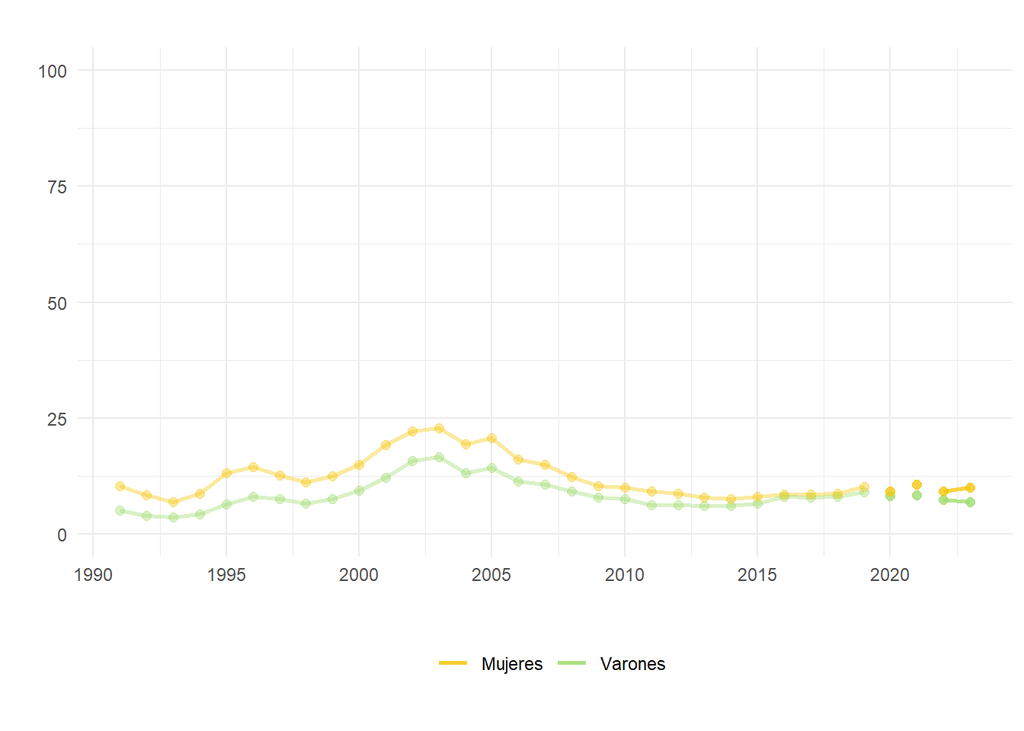

#### Tabla

|  | NOMINDICADOR | PAÍS | UNIDAD_GEOGRÁFICA | SEXO | ANIO | VALOR |
| --- | --- | --- | --- | --- | --- | --- |
| 31 | TASA DE SUBEMPLEO | URUGUAY | URBANO (MÁS DE 5.000 HABITANTES) | MUJERES | 1991 | 10.3 |
| 32 | TASA DE SUBEMPLEO | URUGUAY | URBANO (MÁS DE 5.000 HABITANTES) | MUJERES | 1992 | 8.3 |
| 33 | TASA DE SUBEMPLEO | URUGUAY | URBANO (MÁS DE 5.000 HABITANTES) | MUJERES | 1993 | 6.9 |
| 34 | TASA DE SUBEMPLEO | URUGUAY | URBANO (MÁS DE 5.000 HABITANTES) | MUJERES | 1994 | 8.7 |
| 35 | TASA DE SUBEMPLEO | URUGUAY | URBANO (MÁS DE 5.000 HABITANTES) | MUJERES | 1995 | 13.1 |
| 36 | TASA DE SUBEMPLEO | URUGUAY | URBANO (MÁS DE 5.000 HABITANTES) | MUJERES | 1996 | 14.4 |
| 37 | TASA DE SUBEMPLEO | URUGUAY | URBANO (MÁS DE 5.000 HABITANTES) | MUJERES | 1997 | 12.6 |
| 38 | TASA DE SUBEMPLEO | URUGUAY | URBANO (MÁS DE 5.000 HABITANTES) | MUJERES | 1998 | 11.2 |
| 39 | TASA DE SUBEMPLEO | URUGUAY | URBANO (MÁS DE 5.000 HABITANTES) | MUJERES | 1999 | 12.5 |
| 40 | TASA DE SUBEMPLEO | URUGUAY | URBANO (MÁS DE 5.000 HABITANTES) | MUJERES | 2000 | 15 |

[output cut: 56 more lines]

#### Ficha Técnica

> **Definición:** Proporción de personas ocupadas que desean trabajar más horas

> **Forma de cálculo:** (Número de personas que trabajan menos de 40 hs. semanales y desea trabajar más horas / Población ocupada)*100

> **Advertencia:** Desde marzo de 2020 hasta junio de 2021 se interrumpió el relevamiento presencial y se aplicó de manera telefónica un cuestionario restringido con el objetivo de continuar publicando los indicadores de ingresos y mercado de trabajo. En ese período la encuesta pasó a ser de paneles rotativos elegidos al azar a partir de los casos respondentes del año anterior.  
> En julio de 2021 el INE retomó la realización de encuestas presenciales, pero introdujo un cambio metodológico, ya que la ECH pasa a ser una encuesta de panel rotativo con periodicidad mensual compuesta por seis paneles o grupos de rotación, cada uno de los cuales es una muestra representativa de la población. Con esta nueva metodología, cada hogar seleccionado participa durante seis meses de la ECH.  
> Para 2020, este indicador se construye con la encuesta presencial hasta marzo de 2020 y, posteriormente, con la encuesta telefónica panel. Para 2021, este indicador se calcula a partir de la encuesta telefónica del primer semestre de 2021 y el formulario telefónico de modalidad panel del segundo semestre de 2021. En el segundo semestre, el quintil de ingresos y la condición de pobreza del hogar corresponde a los ingresos declarados durante la implantación del panel en la encuesta presencial. A partir del año 2022, el indicador se calcula con base en la encuesta telefónica panel.

#### Código en R

```r
### Estimación de valores 2022 ###

# Para sintaxix de años anteriores consultar:
# https://osf.io/dyzg8/files/osfstorage#

# ~~~~~~~~~~~~~~~~~~~~~~~~~~~~~~~~~~~~~~~~~~~~~~~~~~~~~~~~~~~~~~~~~~~~~~~~~~~ #

### Carga de paquetes ###

# Instalar si es necesario:
#install.packages("rio")
#install.packages("srvyr")
#install.packages("tidyverse")

library(rio)
library(srvyr)
library(tidyverse)


# ~~~~~~~~~~~~~~~~~~~~~~~~~~~~~~~~~~~~~~~~~~~~~~~~~~~~~~~~~~~~~~~~~~~~~~~~~~~ #

### Descarga bases ECH 2022 (INE) de repositorio UMAD-FCS ###

download.file(
  url = "https://osf.io/download/xnzta/",
  destfile = "ECH_men_22.Rdata"
)

# ~~~~~~~~~~~~~~~~~~~~~~~~~~~~~~~~~~~~~~~~~~~~~~~~~~~~~~~~~~~~~~~~~~~~~~~~~~~ #

### Carga de bases ###

bases_men       <- rio::import("Bases/ECH_men_22.csv")

# ~~~~~~~~~~~~~~~~~~~~~~~~~~~~~~~~~~~~~~~~~~~~~~~~~~~~~~~~~~~~~~~~~~~~~~~~~~~ #


## Generación de nuevas variables ###


# Ocupados

bases_men <- bases_men %>% dplyr::mutate(ocup = ifelse(POBPCOAC==2, 1, 0))


# Subempleo

bases_men <- bases_men %>% dplyr::mutate(bc_subocupado = ifelse(f102 == 1 &
                                                                  f104 == 5 &
                                                                  bc_horas > 0 &
                                                                  bc_horas < 40, 1, 0))




# ~~~~~~~~~~~~~~~~~~~~~~~~~~~~~~~~~~~~~~~~~~~~~~~~~~~~~~~~~~~~~~~~~~~~~~~~~~~ #

### Información de muestreo ###

base_men_svy <- srvyr::as_survey_design(bases_men, ids = ID, weights = w)


# ~~~~~~~~~~~~~~~~~~~~~~~~~~~~~~~~~~~~~~~~~~~~~~~~~~~~~~~~~~~~~~~~~~~~~~~~~~~ #

### Estimación de indicadores ###


###  Tasa de subempleo según sexo

a_sexo <- function(x) {
  x <- base_men_svy %>%
    filter(bc_pe2 == x & ocup == 1 & (region_4 == 1 | region_4 == 2)) %>%
    srvyr::group_by(mes) %>%
    srvyr::summarise(colname = srvyr::survey_mean(bc_subocupado, na.rm=T))
  x <- mean(x$colname)
}

a_e_sexo <- numeric()

for(i in 1:2){
  a_e_sexo[i] <- a_sexo(x = i)
}


# ~~~~~~~~~~~~~~~~~~~~~~~~~~~~~~~~~~~~~~~~~~~~~~~~~~~~~~~~~~~~~~~~~~~~~~~~~~~ #
```

Fuente: Unidad de Métodos y Acceso a Datos (UMAD), Facultad de Ciencias Sociales (FCS-UdelaR), a partir de la ECH del Instituto Nacional de Estadística (INE) compatibilizada por el Instituto de Economía (IECON) (2019) y ECH-INE (2020 a 2022)

Nota: La transparencia de colores representa cambios metodológicos en el relevamiento de las ECH. La línea se discontinúa en aquellos años en que ocurre el cambio (ver Ficha Técnica).

El porcentaje de personas ocupadas que no aportan a la seguridad social es un indicador de informalidad y de falta de garantías sociales y ejercicio de derechos laborales por parte de esta población. El mismo presenta un descenso constante desde el año 2004 hasta el año 2014, año en que la proporción tiende a estabilizarse.

Este porcentaje es levemente mayor para las mujeres que para los varones entre 2004 y 2012, año a partir del cual esta relación se invierte.

##### **Porcentaje de personas ocupadas que no están registradas en la seguridad social en la ocupación principal**

##### País Urbano, 2001 - 2023

#### Gráfico

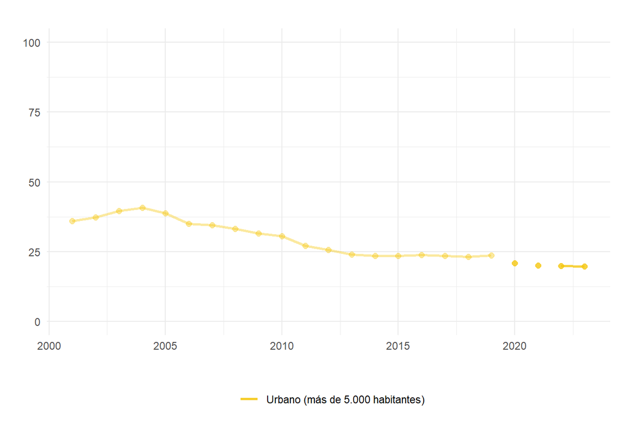

#### Tabla

|  | NOMINDICADOR | PAÍS | UNIDAD_GEOGRÁFICA | ANIO | VALOR |
| --- | --- | --- | --- | --- | --- |
| 1 | PORCENTAJE DE OCUPADOS NO REGISTRADOS EN SEGURIDAD SOCIAL EN OCUPACIÓN PRINCIPAL | URUGUAY | URBANO (MÁS DE 5.000 HABITANTES) | 2001 | 36 |
| 2 | PORCENTAJE DE OCUPADOS NO REGISTRADOS EN SEGURIDAD SOCIAL EN OCUPACIÓN PRINCIPAL | URUGUAY | URBANO (MÁS DE 5.000 HABITANTES) | 2002 | 37.2 |
| 3 | PORCENTAJE DE OCUPADOS NO REGISTRADOS EN SEGURIDAD SOCIAL EN OCUPACIÓN PRINCIPAL | URUGUAY | URBANO (MÁS DE 5.000 HABITANTES) | 2003 | 39.5 |
| 4 | PORCENTAJE DE OCUPADOS NO REGISTRADOS EN SEGURIDAD SOCIAL EN OCUPACIÓN PRINCIPAL | URUGUAY | URBANO (MÁS DE 5.000 HABITANTES) | 2004 | 40.7 |
| 5 | PORCENTAJE DE OCUPADOS NO REGISTRADOS EN SEGURIDAD SOCIAL EN OCUPACIÓN PRINCIPAL | URUGUAY | URBANO (MÁS DE 5.000 HABITANTES) | 2005 | 38.7 |
| 6 | PORCENTAJE DE OCUPADOS NO REGISTRADOS EN SEGURIDAD SOCIAL EN OCUPACIÓN PRINCIPAL | URUGUAY | URBANO (MÁS DE 5.000 HABITANTES) | 2006 | 34.9 |
| 7 | PORCENTAJE DE OCUPADOS NO REGISTRADOS EN SEGURIDAD SOCIAL EN OCUPACIÓN PRINCIPAL | URUGUAY | URBANO (MÁS DE 5.000 HABITANTES) | 2007 | 34.4 |
| 8 | PORCENTAJE DE OCUPADOS NO REGISTRADOS EN SEGURIDAD SOCIAL EN OCUPACIÓN PRINCIPAL | URUGUAY | URBANO (MÁS DE 5.000 HABITANTES) | 2008 | 33.1 |
| 9 | PORCENTAJE DE OCUPADOS NO REGISTRADOS EN SEGURIDAD SOCIAL EN OCUPACIÓN PRINCIPAL | URUGUAY | URBANO (MÁS DE 5.000 HABITANTES) | 2009 | 31.6 |
| 10 | PORCENTAJE DE OCUPADOS NO REGISTRADOS EN SEGURIDAD SOCIAL EN OCUPACIÓN PRINCIPAL | URUGUAY | URBANO (MÁS DE 5.000 HABITANTES) | 2010 | 30.6 |

[output cut: 13 more lines]

#### Ficha Técnica

> **Definición:** Porcentaje de personas ocupadas que no aportan a la seguridad social

> **Forma de cálculo:** (Número de personas ocupadas que no aportan a la seguridad social en su ocupación principal/Número de personas ocupadas)*100

> **Advertencia:** Desde marzo de 2020 hasta junio de 2021 se interrumpió el relevamiento presencial y se aplicó de manera telefónica un cuestionario restringido con el objetivo de continuar publicando los indicadores de ingresos y mercado de trabajo. En ese período la encuesta pasó a ser de paneles rotativos elegidos al azar a partir de los casos respondentes del año anterior.  
> En julio de 2021 el INE retomó la realización de encuestas presenciales, pero introdujo un cambio metodológico, ya que la ECH pasa a ser una encuesta de panel rotativo con periodicidad mensual compuesta por seis paneles o grupos de rotación, cada uno de los cuales es una muestra representativa de la población. Con esta nueva metodología, cada hogar seleccionado participa durante seis meses de la ECH.  
> Para 2020, este indicador se construye con la encuesta presencial hasta marzo de 2020 y, posteriormente, con la encuesta telefónica panel. Para 2021, este indicador se calcula a partir de la encuesta telefónica del primer semestre de 2021 y el formulario telefónico de modalidad panel del segundo semestre de 2021. En el segundo semestre, el quintil de ingresos y la condición de pobreza del hogar corresponde a los ingresos declarados durante la implantación del panel en la encuesta presencial. A partir del año 2022, el indicador se calcula con base en la encuesta telefónica panel.

#### Código en R

```r
### Estimación de valores 2022 ###

# Para sintaxix de años anteriores consultar:
# https://osf.io/dyzg8/files/osfstorage#

# ~~~~~~~~~~~~~~~~~~~~~~~~~~~~~~~~~~~~~~~~~~~~~~~~~~~~~~~~~~~~~~~~~~~~~~~~~~~ #

### Carga de paquetes ###

# Instalar si es necesario:
#install.packages("rio")
#install.packages("srvyr")
#install.packages("tidyverse")

library(rio)
library(srvyr)
library(tidyverse)


# ~~~~~~~~~~~~~~~~~~~~~~~~~~~~~~~~~~~~~~~~~~~~~~~~~~~~~~~~~~~~~~~~~~~~~~~~~~~ #

### Descarga bases ECH 2022 (INE) de repositorio UMAD-FCS ###


download.file(
  url = "https://osf.io/download/xnzta/",
  destfile = "ECH_men_22.Rdata"
)

# ~~~~~~~~~~~~~~~~~~~~~~~~~~~~~~~~~~~~~~~~~~~~~~~~~~~~~~~~~~~~~~~~~~~~~~~~~~~ #

### Carga de bases ###

bases_men       <- rio::import("Bases/ECH_men_22.csv")

# ~~~~~~~~~~~~~~~~~~~~~~~~~~~~~~~~~~~~~~~~~~~~~~~~~~~~~~~~~~~~~~~~~~~~~~~~~~~ #


## Generación de nuevas variables ###


# Ocupados

bases_men <- bases_men %>% dplyr::mutate(ocup = ifelse(POBPCOAC==2, 1, 0))


# No aporte a SS en trabajo principal

bases_men <- bases_men %>% dplyr::mutate(bc_register = ifelse(f82 == 1, 0, 1))




# ~~~~~~~~~~~~~~~~~~~~~~~~~~~~~~~~~~~~~~~~~~~~~~~~~~~~~~~~~~~~~~~~~~~~~~~~~~~ #

### Información de muestreo ###

base_men_svy <- srvyr::as_survey_design(bases_men, ids = ID, weights = w)


# ~~~~~~~~~~~~~~~~~~~~~~~~~~~~~~~~~~~~~~~~~~~~~~~~~~~~~~~~~~~~~~~~~~~~~~~~~~~ #

### Estimación de indicadores ###


###  Porcentaje de ocupados que no aportan a la seguridad social en ocupación principal

a_mes <- base_men_svy %>%
  srvyr::filter(ocup == 1 & (region_4 == 1 | region_4 == 2)) %>%
  srvyr::group_by(mes) %>%
  srvyr::summarise(colname = srvyr::survey_mean(bc_register, na.rm=T))

c_ano <- mean(as.numeric(a_mes$colname))


# ~~~~~~~~~~~~~~~~~~~~~~~~~~~~~~~~~~~~~~~~~~~~~~~~~~~~~~~~~~~~~~~~~~~~~~~~~~~ #
```

Fuente: Unidad de Métodos y Acceso a Datos (UMAD), Facultad de Ciencias Sociales (FCS-UdelaR), a partir de la ECH del Instituto Nacional de Estadística (INE) compatibilizada por el Instituto de Economía (IECON) (2019) y ECH-INE (2020 a 2022)

Nota: La transparencia de colores representa cambios metodológicos en el relevamiento de las ECH. La línea se discontinúa en aquellos años en que ocurre el cambio (ver Ficha Técnica).

##### **Porcentaje de personas ocupadas que no están registradas en la seguridad social en la ocupación principal, según sexo**

##### País Urbano, 2001 - 2023

#### Gráfico

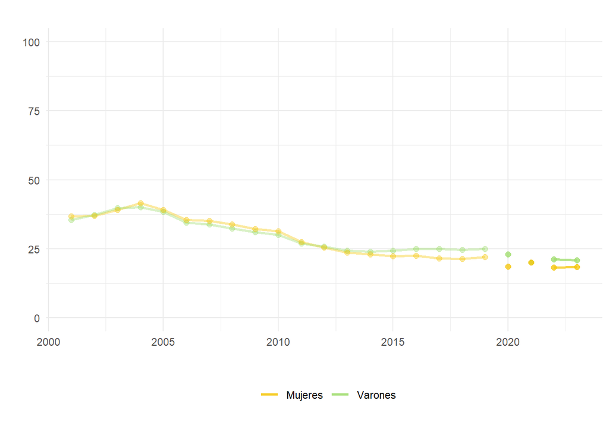

#### Tabla

|  | NOMINDICADOR | PAÍS | UNIDAD_GEOGRÁFICA | SEXO | ANIO | VALOR |
| --- | --- | --- | --- | --- | --- | --- |
| 21 | PORCENTAJE DE OCUPADOS NO REGISTRADOS EN SEGURIDAD SOCIAL EN OCUPACIÓN PRINCIPAL | URUGUAY | URBANO (MÁS DE 5.000 HABITANTES) | MUJERES | 2001 | 36.8 |
| 22 | PORCENTAJE DE OCUPADOS NO REGISTRADOS EN SEGURIDAD SOCIAL EN OCUPACIÓN PRINCIPAL | URUGUAY | URBANO (MÁS DE 5.000 HABITANTES) | MUJERES | 2002 | 37 |
| 23 | PORCENTAJE DE OCUPADOS NO REGISTRADOS EN SEGURIDAD SOCIAL EN OCUPACIÓN PRINCIPAL | URUGUAY | URBANO (MÁS DE 5.000 HABITANTES) | MUJERES | 2003 | 39.1 |
| 24 | PORCENTAJE DE OCUPADOS NO REGISTRADOS EN SEGURIDAD SOCIAL EN OCUPACIÓN PRINCIPAL | URUGUAY | URBANO (MÁS DE 5.000 HABITANTES) | MUJERES | 2004 | 41.5 |
| 25 | PORCENTAJE DE OCUPADOS NO REGISTRADOS EN SEGURIDAD SOCIAL EN OCUPACIÓN PRINCIPAL | URUGUAY | URBANO (MÁS DE 5.000 HABITANTES) | MUJERES | 2005 | 39.1 |
| 26 | PORCENTAJE DE OCUPADOS NO REGISTRADOS EN SEGURIDAD SOCIAL EN OCUPACIÓN PRINCIPAL | URUGUAY | URBANO (MÁS DE 5.000 HABITANTES) | MUJERES | 2006 | 35.4 |
| 27 | PORCENTAJE DE OCUPADOS NO REGISTRADOS EN SEGURIDAD SOCIAL EN OCUPACIÓN PRINCIPAL | URUGUAY | URBANO (MÁS DE 5.000 HABITANTES) | MUJERES | 2007 | 35.1 |
| 28 | PORCENTAJE DE OCUPADOS NO REGISTRADOS EN SEGURIDAD SOCIAL EN OCUPACIÓN PRINCIPAL | URUGUAY | URBANO (MÁS DE 5.000 HABITANTES) | MUJERES | 2008 | 33.9 |
| 29 | PORCENTAJE DE OCUPADOS NO REGISTRADOS EN SEGURIDAD SOCIAL EN OCUPACIÓN PRINCIPAL | URUGUAY | URBANO (MÁS DE 5.000 HABITANTES) | MUJERES | 2009 | 32.1 |
| 30 | PORCENTAJE DE OCUPADOS NO REGISTRADOS EN SEGURIDAD SOCIAL EN OCUPACIÓN PRINCIPAL | URUGUAY | URBANO (MÁS DE 5.000 HABITANTES) | MUJERES | 2010 | 31.3 |

[output cut: 36 more lines]

#### Ficha Técnica

> **Definición:** Porcentaje de personas ocupadas que no aportan a la seguridad social

> **Forma de cálculo:** (Número de personas ocupadas que no aportan a la seguridad social en su ocupación principal/Número de personas ocupadas)*100

> **Advertencia:** Desde marzo de 2020 hasta junio de 2021 se interrumpió el relevamiento presencial y se aplicó de manera telefónica un cuestionario restringido con el objetivo de continuar publicando los indicadores de ingresos y mercado de trabajo. En ese período la encuesta pasó a ser de paneles rotativos elegidos al azar a partir de los casos respondentes del año anterior.  
> En julio de 2021 el INE retomó la realización de encuestas presenciales, pero introdujo un cambio metodológico, ya que la ECH pasa a ser una encuesta de panel rotativo con periodicidad mensual compuesta por seis paneles o grupos de rotación, cada uno de los cuales es una muestra representativa de la población. Con esta nueva metodología, cada hogar seleccionado participa durante seis meses de la ECH.  
> Para 2020, este indicador se construye con la encuesta presencial hasta marzo de 2020 y, posteriormente, con la encuesta telefónica panel. Para 2021, este indicador se calcula a partir de la encuesta telefónica del primer semestre de 2021 y el formulario telefónico de modalidad panel del segundo semestre de 2021. En el segundo semestre, el quintil de ingresos y la condición de pobreza del hogar corresponde a los ingresos declarados durante la implantación del panel en la encuesta presencial. A partir del año 2022, el indicador se calcula con base en la encuesta telefónica panel.

#### Código en R

```r
### Estimación de valores 2022 ###

# Para sintaxix de años anteriores consultar:
# https://osf.io/dyzg8/files/osfstorage#

# ~~~~~~~~~~~~~~~~~~~~~~~~~~~~~~~~~~~~~~~~~~~~~~~~~~~~~~~~~~~~~~~~~~~~~~~~~~~ #

### Carga de paquetes ###

# Instalar si es necesario:
#install.packages("rio")
#install.packages("srvyr")
#install.packages("tidyverse")

library(rio)
library(srvyr)
library(tidyverse)


# ~~~~~~~~~~~~~~~~~~~~~~~~~~~~~~~~~~~~~~~~~~~~~~~~~~~~~~~~~~~~~~~~~~~~~~~~~~~ #

### Descarga bases ECH 2022 (INE) de repositorio UMAD-FCS ###

download.file(
  url = "https://osf.io/download/xnzta/",
  destfile = "ECH_men_22.Rdata"
)

# ~~~~~~~~~~~~~~~~~~~~~~~~~~~~~~~~~~~~~~~~~~~~~~~~~~~~~~~~~~~~~~~~~~~~~~~~~~~ #

### Carga de bases ###

bases_men       <- rio::import("Bases/ECH_men_22.csv")

# ~~~~~~~~~~~~~~~~~~~~~~~~~~~~~~~~~~~~~~~~~~~~~~~~~~~~~~~~~~~~~~~~~~~~~~~~~~~ #


## Generación de nuevas variables ###


# Ocupados

bases_men <- bases_men %>% dplyr::mutate(ocup = ifelse(POBPCOAC==2, 1, 0))


# No aporte a SS en trabajo principal

bases_men <- bases_men %>% dplyr::mutate(bc_register = ifelse(f82 == 1, 0, 1))


# ~~~~~~~~~~~~~~~~~~~~~~~~~~~~~~~~~~~~~~~~~~~~~~~~~~~~~~~~~~~~~~~~~~~~~~~~~~~ #

### Información de muestreo ###

base_men_svy <- srvyr::as_survey_design(bases_men, ids = ID, weights = w)


# ~~~~~~~~~~~~~~~~~~~~~~~~~~~~~~~~~~~~~~~~~~~~~~~~~~~~~~~~~~~~~~~~~~~~~~~~~~~ #

### Estimación de indicadores ###


###  Porcentaje de ocupados que no aportan a la seguridad social en ocupación principal según sexo

a_sexo <- function(x) {
  x <- base_men_svy %>%
    filter(bc_pe2 == x & ocup == 1 & (region_4 == 1 | region_4 == 2)) %>%
    srvyr::group_by(mes) %>%
    srvyr::summarise(colname = srvyr::survey_mean(bc_register, na.rm=T))
  x <- mean(x$colname)
}

a_e_sexo <- numeric()

for(i in 1:2){
  a_e_sexo[i] <- a_sexo(x = i)
}


# ~~~~~~~~~~~~~~~~~~~~~~~~~~~~~~~~~~~~~~~~~~~~~~~~~~~~~~~~~~~~~~~~~~~~~~~~~~~ #
```

Fuente: Unidad de Métodos y Acceso a Datos (UMAD), Facultad de Ciencias Sociales (FCS-UdelaR), a partir de la ECH del Instituto Nacional de Estadística (INE) compatibilizada por el Instituto de Economía (IECON) (2019) y ECH-INE (2020 a 2022)

Nota: La transparencia de colores representa cambios metodológicos en el relevamiento de las ECH. La línea se discontinúa en aquellos años en que ocurre el cambio (ver Ficha Técnica).

El porcentaje de personas ocupadas sin restricciones en el empleo (se considera subempleo y no aporte a la seguridad social) aumenta entre 2006 y 2021. Esta disminución tiene como correlato, principalmente, una disminución del porcentaje de personas que no aportan a la seguridad social.

##### **Distribución de personas ocupadas según restricciones en el empleo**

##### Total país, 2006 - 2023

#### Gráfico

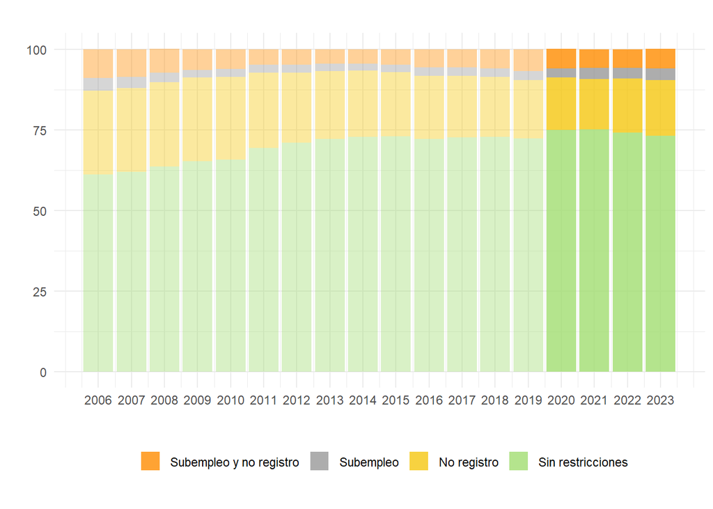

#### Tabla

|  | NOMINDICADOR | PAÍS | UNIDAD_GEOGRÁFICA | UNIDAD | ANIO | VALOR |
| --- | --- | --- | --- | --- | --- | --- |
| 3 | DISTRIBUCIÓN DE PERSONAS SEGÚN RESTRICCIONES EN EL EMPLEO | URUGUAY | TOTAL PAÍS | No registro | 2006 | 26 |
| 4 | DISTRIBUCIÓN DE PERSONAS SEGÚN RESTRICCIONES EN EL EMPLEO | URUGUAY | TOTAL PAÍS | Sin restricciones | 2006 | 61.2 |
| 1 | DISTRIBUCIÓN DE PERSONAS SEGÚN RESTRICCIONES EN EL EMPLEO | URUGUAY | TOTAL PAÍS | Subempleo | 2006 | 3.8 |
| 2 | DISTRIBUCIÓN DE PERSONAS SEGÚN RESTRICCIONES EN EL EMPLEO | URUGUAY | TOTAL PAÍS | Subempleo y no registro | 2006 | 9 |
| 8 | DISTRIBUCIÓN DE PERSONAS SEGÚN RESTRICCIONES EN EL EMPLEO | URUGUAY | TOTAL PAÍS | No registro | 2007 | 26 |
| 6 | DISTRIBUCIÓN DE PERSONAS SEGÚN RESTRICCIONES EN EL EMPLEO | URUGUAY | TOTAL PAÍS | Sin restricciones | 2007 | 61.9 |
| 7 | DISTRIBUCIÓN DE PERSONAS SEGÚN RESTRICCIONES EN EL EMPLEO | URUGUAY | TOTAL PAÍS | Subempleo | 2007 | 3.5 |
| 5 | DISTRIBUCIÓN DE PERSONAS SEGÚN RESTRICCIONES EN EL EMPLEO | URUGUAY | TOTAL PAÍS | Subempleo y no registro | 2007 | 8.6 |
| 12 | DISTRIBUCIÓN DE PERSONAS SEGÚN RESTRICCIONES EN EL EMPLEO | URUGUAY | TOTAL PAÍS | No registro | 2008 | 26.2 |
| 11 | DISTRIBUCIÓN DE PERSONAS SEGÚN RESTRICCIONES EN EL EMPLEO | URUGUAY | TOTAL PAÍS | Sin restricciones | 2008 | 63.6 |

[output cut: 62 more lines]

#### Ficha Técnica

> **Definición:** Distribución de personas ocupadas según restricciones al empleo

> **Forma de cálculo:** (Cantidad de personas en dichas categorías / Cantidad total de personas ocupadas)*100

#### Código en R

```r
### Estimación de valores 2022 ###

# Para sintaxix de años anteriores consultar:
# https://osf.io/dyzg8/files/osfstorage#

# ~~~~~~~~~~~~~~~~~~~~~~~~~~~~~~~~~~~~~~~~~~~~~~~~~~~~~~~~~~~~~~~~~~~~~~~~~~~ #

### Carga de paquetes ###

# Instalar si es necesario:
#install.packages("rio")
#install.packages("srvyr")
#install.packages("tidyverse")

library(rio)
library(srvyr)
library(tidyverse)


# ~~~~~~~~~~~~~~~~~~~~~~~~~~~~~~~~~~~~~~~~~~~~~~~~~~~~~~~~~~~~~~~~~~~~~~~~~~~ #

### Descarga bases ECH 2022 (INE) de repositorio UMAD-FCS ###

download.file(
  url = "https://osf.io/download/rehz2/",
  destfile = "Base anual 2022.Rdata"
)

# ~~~~~~~~~~~~~~~~~~~~~~~~~~~~~~~~~~~~~~~~~~~~~~~~~~~~~~~~~~~~~~~~~~~~~~~~~~~ #

### Carga de bases ###

base            <- rio::import("Bases/Base anual 2022.csv")

# ~~~~~~~~~~~~~~~~~~~~~~~~~~~~~~~~~~~~~~~~~~~~~~~~~~~~~~~~~~~~~~~~~~~~~~~~~~~ #


## Generación de nuevas variables ###


# Ocupados

base <- base %>% dplyr::mutate(ocup = ifelse(POBPCOAC==2, 1, 0))


# No aporte a SS en trabajo principal y secundario

base <- base %>% dplyr::mutate(bc_register2 = ifelse(f96 == 1 |
                                                       f82 == 1, 0, 1))


# Subempleo

base <- base  %>% dplyr::mutate(bc_horas = f85+f98)
base <- base %>% dplyr::mutate(bc_subocupado = ifelse(f102 == 1 &
                                                        f104 == 5 &
                                                        bc_horas > 0 &
                                                        bc_horas < 40, 1, 0))

# Restricciones al empleo

base <- base %>% dplyr::mutate(nre = ifelse(bc_register2 == 1 &
                                              bc_subocupado == 0 , 1, 0))
base <- base %>% dplyr::mutate(sub = ifelse(bc_register2 == 0 &
                                              bc_subocupado == 1 , 1, 0))
base <- base %>% dplyr::mutate(amb = ifelse(bc_register2 == 1 &
                                              bc_subocupado == 1 , 1, 0))
base <- base %>% dplyr::mutate(sin = ifelse(bc_register2 == 0 &
                                              bc_subocupado == 0 , 1, 0))

restricciones <- c("nre", "sub", "amb", "sin")



# ~~~~~~~~~~~~~~~~~~~~~~~~~~~~~~~~~~~~~~~~~~~~~~~~~~~~~~~~~~~~~~~~~~~~~~~~~~~ #

### Información de muestreo ###

base_svy <- srvyr::as_survey_design(base, ids = ID, weights = w_ano)


# ~~~~~~~~~~~~~~~~~~~~~~~~~~~~~~~~~~~~~~~~~~~~~~~~~~~~~~~~~~~~~~~~~~~~~~~~~~~ #

### Estimación de indicadores ###


###  Distribución de personas ocupadas según restricciones al empleo

Restricciones <- c("No registradas",
                   "Subempleadas",
                   "No registradas y subempleadas",
                   "Sin restricciones al empleo")

# Total

base <- base_svy %>% filter(ocup == 1)

c_ano <- sapply(base$variables %>% select(restricciones), function(x){
  base %>%
    filter(ocup == 1) %>%
    srvyr::summarise(VALOR_1 = srvyr::survey_mean(x, na.rm = TRUE))
})

c_ano <- data.frame(t(a_sem))
c_ano <- c_ano %>% dplyr::mutate(RESTRICCIONES_AL_EMPLEO = Restricciones)


# ~~~~~~~~~~~~~~~~~~~~~~~~~~~~~~~~~~~~~~~~~~~~~~~~~~~~~~~~~~~~~~~~~~~~~~~~~~~ #
```

Fuente: Unidad de Métodos y Acceso a Datos (UMAD), Facultad de Ciencias Sociales (FCS-UdelaR), a partir de la ECH del Instituto Nacional de Estadística (INE) compatibilizada por el Instituto de Economía (IECON) (2019) y ECH-INE (2020 a 2022)

Nota: La transparencia de colores representa cambios metodológicos en el relevamiento de las ECH (ver Ficha Técnica).

# **Nivel y suficiencia de ingresos laborales**

## **Nivel de ingresos laborales**

El siguiente indicador presenta el promedio de ingresos que reciben las personas ocupadas por hora de trabajo en su ocupación princial. El mismo se encuentra deflactado a precios de diciembre del año 2006 por lo cual habilita dar cuenta de la evolución real durante el período. Desde 2001 a 2003, el indicador presenta una caída y a partir del año 2004 presenta una tendencia creciente en el país urbano. A partir de 2020 se observa una caída del promedio de ingresos laborales por hora de trabajo luego de 16 años.

##### **Salario promedio por hora de trabajo remunerado en ocupación principal (cte. base diciembre 2006)**

##### País urbano, 2001 - 2023

#### Gráfico

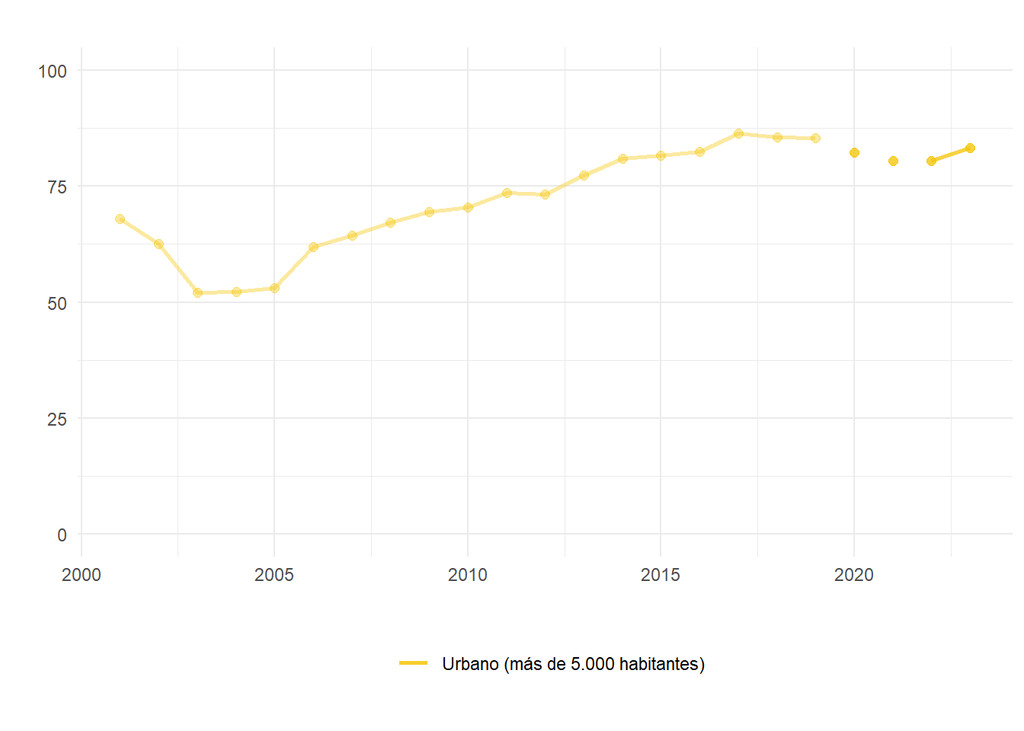

#### Tabla

|  | NOMINDICADOR | PAÍS | UNIDAD_GEOGRÁFICA | ANIO | VALOR |
| --- | --- | --- | --- | --- | --- |
| 1 | INGRESO POR HORA PROMEDIO EN OCUPACIÓN PRINCIPAL (DEF. BASE 2010) | URUGUAY | URBANO (MÁS DE 5.000 HABITANTES) | 2001 | 67.979995668566 |
| 2 | INGRESO POR HORA PROMEDIO EN OCUPACIÓN PRINCIPAL (DEF. BASE 2010) | URUGUAY | URBANO (MÁS DE 5.000 HABITANTES) | 2002 | 62.5118100475967 |
| 3 | INGRESO POR HORA PROMEDIO EN OCUPACIÓN PRINCIPAL (DEF. BASE 2010) | URUGUAY | URBANO (MÁS DE 5.000 HABITANTES) | 2003 | 52.0692864641852 |
| 4 | INGRESO POR HORA PROMEDIO EN OCUPACIÓN PRINCIPAL (DEF. BASE 2010) | URUGUAY | URBANO (MÁS DE 5.000 HABITANTES) | 2004 | 52.1585588810241 |
| 5 | INGRESO POR HORA PROMEDIO EN OCUPACIÓN PRINCIPAL (DEF. BASE 2010) | URUGUAY | URBANO (MÁS DE 5.000 HABITANTES) | 2005 | 53.0646578853344 |
| 6 | INGRESO POR HORA PROMEDIO EN OCUPACIÓN PRINCIPAL (DEF. BASE 2010) | URUGUAY | URBANO (MÁS DE 5.000 HABITANTES) | 2006 | 61.8721452457604 |
| 7 | INGRESO POR HORA PROMEDIO EN OCUPACIÓN PRINCIPAL (DEF. BASE 2010) | URUGUAY | URBANO (MÁS DE 5.000 HABITANTES) | 2007 | 64.4356741617542 |
| 8 | INGRESO POR HORA PROMEDIO EN OCUPACIÓN PRINCIPAL (DEF. BASE 2010) | URUGUAY | URBANO (MÁS DE 5.000 HABITANTES) | 2008 | 67.1499789273131 |
| 9 | INGRESO POR HORA PROMEDIO EN OCUPACIÓN PRINCIPAL (DEF. BASE 2010) | URUGUAY | URBANO (MÁS DE 5.000 HABITANTES) | 2009 | 69.523457753036 |
| 10 | INGRESO POR HORA PROMEDIO EN OCUPACIÓN PRINCIPAL (DEF. BASE 2010) | URUGUAY | URBANO (MÁS DE 5.000 HABITANTES) | 2010 | 70.4793718378181 |

[output cut: 13 more lines]

#### Ficha Técnica

> **Definición:** Salario promedio por hora de trabajo remunerado en ocupación princial.

> **Forma de cálculo:** Promedio de remuneración por hora de trabajo en ocupación principal.

> **Advertencia:** Desde marzo de 2020 hasta junio de 2021 se interrumpió el relevamiento presencial y se aplicó de manera telefónica un cuestionario restringido con el objetivo de continuar publicando los indicadores de ingresos y mercado de trabajo. En ese período la encuesta pasó a ser de paneles rotativos elegidos al azar a partir de los casos respondentes del año anterior.  
> En julio de 2021 el INE retomó la realización de encuestas presenciales, pero introdujo un cambio metodológico, ya que la ECH pasa a ser una encuesta de panel rotativo con periodicidad mensual compuesta por seis paneles o grupos de rotación, cada uno de los cuales es una muestra representativa de la población. Con esta nueva metodología, cada hogar seleccionado participa durante seis meses de la ECH.  
> Para 2020, este indicador se construye con la encuesta presencial hasta marzo de 2020 y, posteriormente, con la encuesta telefónica panel. Para 2021, este indicador se calcula a partir de la encuesta telefónica del primer semestre de 2021 y el formulario presencial de modalidad panel del segundo semestre de 2021. En el segundo semestre, el quintil de ingresos y la condición de pobreza del hogar corresponde a los ingresos declarados durante la implantación del panel en la encuesta presencial. A partir del año 2022, el indicador se calcula con base en la encuesta presencial.

#### Código en R

```r
### Estimación de valores 2022 ###

# Para sintaxix de años anteriores consultar:
# https://osf.io/dyzg8/files/osfstorage#

# ~~~~~~~~~~~~~~~~~~~~~~~~~~~~~~~~~~~~~~~~~~~~~~~~~~~~~~~~~~~~~~~~~~~~~~~~~~~ #

### Carga de paquetes ###

# Instalar si es necesario:
#install.packages("rio")
#install.packages("srvyr")
#install.packages("tidyverse")

library(rio)
library(srvyr)
library(tidyverse)


# ~~~~~~~~~~~~~~~~~~~~~~~~~~~~~~~~~~~~~~~~~~~~~~~~~~~~~~~~~~~~~~~~~~~~~~~~~~~ #

### Descarga bases ECH 2022 (INE) de repositorio UMAD-FCS ###

download.file(
  url = "https://osf.io/download/rehz2/",
  destfile = "Base anual 2022.Rdata"
)


# ~~~~~~~~~~~~~~~~~~~~~~~~~~~~~~~~~~~~~~~~~~~~~~~~~~~~~~~~~~~~~~~~~~~~~~~~~~~ #

### Carga de bases ###

base            <- rio::import("Bases/Base anual 2022.csv")

# ~~~~~~~~~~~~~~~~~~~~~~~~~~~~~~~~~~~~~~~~~~~~~~~~~~~~~~~~~~~~~~~~~~~~~~~~~~~ #


## Generación de nuevas variables ###

#IPC

base <- base %>% dplyr::mutate(bc_ipc_tot = case_when(
  mes == 1 ~  0.310804203,
  mes == 2 ~  0.305354401,
  mes == 3 ~  0.300928439,
  mes == 4 ~  0.297635795,
  mes == 5 ~  0.296181029,
  mes == 6 ~  0.294810362,
  mes == 7 ~  0.293094596,
  mes == 8 ~  0.290852868,
  mes == 9 ~  0.288466429,
  mes == 10 ~ 0.286063926,
  mes == 11 ~ 0.28546134,
  mes == 12 ~ 0.286262936))


# Ocupados

base <- base %>% dplyr::mutate(ocup = ifelse(POBPCOAC==2, 1, 0))


# Salario en ocupación principal

base <- base %>% dplyr::mutate(horamen = f85 * 4.3)
base <- base %>% dplyr::mutate(yhora = PT2/horamen)
base <- base %>% dplyr::mutate(yhoradef = case_when(f85>0 ~ yhora*bc_ipc_tot,
                                                    f85==0 ~ 0))

# ~~~~~~~~~~~~~~~~~~~~~~~~~~~~~~~~~~~~~~~~~~~~~~~~~~~~~~~~~~~~~~~~~~~~~~~~~~~ #

### Información de muestreo ###

base_svy <- srvyr::as_survey_design(base, ids = ID, weights = w_ano)


# ~~~~~~~~~~~~~~~~~~~~~~~~~~~~~~~~~~~~~~~~~~~~~~~~~~~~~~~~~~~~~~~~~~~~~~~~~~~ #

### Estimación de indicadores ###


###  Salario promedio por hora de trabajo remunerado en ocupación principal

c_ano <- base_svy %>%
  srvyr::filter(ocup == 1 & (region_4 == 1 | region_4 == 2) & f85>0) %>%
  srvyr::summarise(colname = srvyr::survey_mean(yhoradef, na.rm=T))


# ~~~~~~~~~~~~~~~~~~~~~~~~~~~~~~~~~~~~~~~~~~~~~~~~~~~~~~~~~~~~~~~~~~~~~~~~~~~ #
```

Fuente: Unidad de Métodos y Acceso a Datos (UMAD), Facultad de Ciencias Sociales (FCS-UdelaR), a partir de la ECH del Instituto Nacional de Estadística (INE) compatibilizada por el Instituto de Economía (IECON) (2019) y ECH-INE (2020 a 2022)

Nota: La transparencia de colores representa cambios metodológicos en el relevamiento de las ECH. La línea se discontinúa en aquellos años en que ocurre el cambio (ver Ficha Técnica).

## **Suficiencia de ingresos**

##### **Porcentaje de personas ocupadas que perciben ingresos por debajo del salario mínimo nacional**

##### País urbano, 2001 - 2023

#### Gráfico

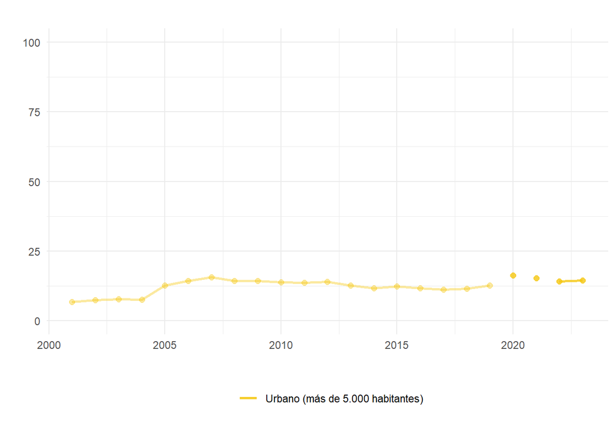

#### Tabla

|  | NOMINDICADOR | PAÍS | UNIDAD_GEOGRÁFICA | ANIO | VALOR |
| --- | --- | --- | --- | --- | --- |
| 1 | PORCENTAJE DE OCUPADOS QUE PERCIBEN UN INGRESO POR DEBAJO DEL SMN | URUGUAY | URBANO (MÁS DE 5.000 HABITANTES) | 2001 | 6.7 |
| 2 | PORCENTAJE DE OCUPADOS QUE PERCIBEN UN INGRESO POR DEBAJO DEL SMN | URUGUAY | URBANO (MÁS DE 5.000 HABITANTES) | 2002 | 7.3 |
| 3 | PORCENTAJE DE OCUPADOS QUE PERCIBEN UN INGRESO POR DEBAJO DEL SMN | URUGUAY | URBANO (MÁS DE 5.000 HABITANTES) | 2003 | 7.7 |
| 4 | PORCENTAJE DE OCUPADOS QUE PERCIBEN UN INGRESO POR DEBAJO DEL SMN | URUGUAY | URBANO (MÁS DE 5.000 HABITANTES) | 2004 | 7.6 |
| 5 | PORCENTAJE DE OCUPADOS QUE PERCIBEN UN INGRESO POR DEBAJO DEL SMN | URUGUAY | URBANO (MÁS DE 5.000 HABITANTES) | 2005 | 12.6 |
| 6 | PORCENTAJE DE OCUPADOS QUE PERCIBEN UN INGRESO POR DEBAJO DEL SMN | URUGUAY | URBANO (MÁS DE 5.000 HABITANTES) | 2006 | 14.3 |
| 7 | PORCENTAJE DE OCUPADOS QUE PERCIBEN UN INGRESO POR DEBAJO DEL SMN | URUGUAY | URBANO (MÁS DE 5.000 HABITANTES) | 2007 | 15.6 |
| 8 | PORCENTAJE DE OCUPADOS QUE PERCIBEN UN INGRESO POR DEBAJO DEL SMN | URUGUAY | URBANO (MÁS DE 5.000 HABITANTES) | 2008 | 14.3 |
| 9 | PORCENTAJE DE OCUPADOS QUE PERCIBEN UN INGRESO POR DEBAJO DEL SMN | URUGUAY | URBANO (MÁS DE 5.000 HABITANTES) | 2009 | 14.3 |
| 10 | PORCENTAJE DE OCUPADOS QUE PERCIBEN UN INGRESO POR DEBAJO DEL SMN | URUGUAY | URBANO (MÁS DE 5.000 HABITANTES) | 2010 | 13.8 |

[output cut: 13 more lines]

#### Ficha Técnica

> **Definición:** Porcentaje de ocupados que perciben ingresos laborales por debajo del salario mínimo nacional (Valores SMN enero 2019).

> **Forma de cálculo:** (Cantidad de personas con ingresos laborales por debajo del SMN / Cantidad total de personas ocupadas)*100

> **Advertencia:** Desde marzo de 2020 hasta junio de 2021 se interrumpió el relevamiento presencial y se aplicó de manera telefónica un cuestionario restringido con el objetivo de continuar publicando los indicadores de ingresos y mercado de trabajo. En ese período la encuesta pasó a ser de paneles rotativos elegidos al azar a partir de los casos respondentes del año anterior.  
> En julio de 2021 el INE retomó la realización de encuestas presenciales, pero introdujo un cambio metodológico, ya que la ECH pasa a ser una encuesta de panel rotativo con periodicidad mensual compuesta por seis paneles o grupos de rotación, cada uno de los cuales es una muestra representativa de la población. Con esta nueva metodología, cada hogar seleccionado participa durante seis meses de la ECH.  
> Para 2020, este indicador se construye con la encuesta presencial hasta marzo de 2020 y, posteriormente, con la encuesta telefónica panel. Para 2021, este indicador se calcula a partir de la encuesta telefónica del primer semestre de 2021 y el formulario presencial de modalidad panel del segundo semestre de 2021. En el segundo semestre, el quintil de ingresos y la condición de pobreza del hogar corresponde a los ingresos declarados durante la implantación del panel en la encuesta presencial. A partir del año 2022, el indicador se calcula con base en la encuesta presencial.

#### Código en R

```r
### Estimación de valores 2022 ###

# Para sintaxix de años anteriores consultar:
# https://osf.io/dyzg8/files/osfstorage#

# ~~~~~~~~~~~~~~~~~~~~~~~~~~~~~~~~~~~~~~~~~~~~~~~~~~~~~~~~~~~~~~~~~~~~~~~~~~~ #

### Carga de paquetes ###

# Instalar si es necesario:
#install.packages("rio")
#install.packages("srvyr")
#install.packages("tidyverse")

library(rio)
library(srvyr)
library(tidyverse)


# ~~~~~~~~~~~~~~~~~~~~~~~~~~~~~~~~~~~~~~~~~~~~~~~~~~~~~~~~~~~~~~~~~~~~~~~~~~~ #

### Descarga bases ECH 2022 (INE) de repositorio UMAD-FCS ###

download.file(
  url = "https://osf.io/download/rehz2/",
  destfile = "Base anual 2022.Rdata"
)

# ~~~~~~~~~~~~~~~~~~~~~~~~~~~~~~~~~~~~~~~~~~~~~~~~~~~~~~~~~~~~~~~~~~~~~~~~~~~ #

### Carga de bases ###

base            <- rio::import("Bases/Base anual 2022.csv")

# ~~~~~~~~~~~~~~~~~~~~~~~~~~~~~~~~~~~~~~~~~~~~~~~~~~~~~~~~~~~~~~~~~~~~~~~~~~~ #


## Generación de nuevas variables ###

smn <- 19364
smn_h = smn/200

base <- base %>% dplyr::mutate(bc_ipc_tot = case_when(
  mes == 1 ~  0.310804203,
  mes == 2 ~  0.305354401,
  mes == 3 ~  0.300928439,
  mes == 4 ~  0.297635795,
  mes == 5 ~  0.296181029,
  mes == 6 ~  0.294810362,
  mes == 7 ~  0.293094596,
  mes == 8 ~  0.290852868,
  mes == 9 ~  0.288466429,
  mes == 10 ~ 0.286063926,
  mes == 11 ~ 0.28546134,
  mes == 12 ~ 0.286262936))

# Ocupados

base <- base %>% dplyr::mutate(ocup = ifelse(POBPCOAC==2, 1, 0))


# Salario en ocupación principal

base <- base %>% dplyr::mutate(horamen = f85 * 4.3)
base <- base %>% dplyr::mutate(yhora = PT2/horamen)
base <- base %>% dplyr::mutate(yhoradef = case_when(f85>0 ~ yhora*bc_ipc_tot,
                                                    f85==0 ~ 0))

# Salario por debajo del salario mínimo nacional

base <- base %>% dplyr::mutate(salario_insuf_smn = ifelse(yhora<smn_h, 1, 0))


# ~~~~~~~~~~~~~~~~~~~~~~~~~~~~~~~~~~~~~~~~~~~~~~~~~~~~~~~~~~~~~~~~~~~~~~~~~~~ #

### Información de muestreo ###

base_svy <- srvyr::as_survey_design(base, ids = ID, weights = w_ano)



# ~~~~~~~~~~~~~~~~~~~~~~~~~~~~~~~~~~~~~~~~~~~~~~~~~~~~~~~~~~~~~~~~~~~~~~~~~~~ #

### Estimación de indicadores ###


###  Porcentaje de personas ocupadas que perciben ingresos por debajo del salario mínimo nacional

c_ano <- base_svy %>%
  srvyr::filter(ocup == 1 & (region_4 == 1 | region_4 == 2)) %>%
  srvyr::summarise(colname = srvyr::survey_mean(salario_insuf_smn, na.rm=T))


# ~~~~~~~~~~~~~~~~~~~~~~~~~~~~~~~~~~~~~~~~~~~~~~~~~~~~~~~~~~~~~~~~~~~~~~~~~~~ #
```

Fuente: Unidad de Métodos y Acceso a Datos (UMAD), Facultad de Ciencias Sociales (FCS-UdelaR), a partir de la ECH del Instituto Nacional de Estadística (INE) compatibilizada por el Instituto de Economía (IECON) (2019) y ECH-INE (2020 a 2022)

Nota: La transparencia de colores representa cambios metodológicos en el relevamiento de las ECH. La línea se discontinúa en aquellos años en que ocurre el cambio (ver Ficha Técnica).

##### **Porcentaje de personas ocupadas que perciben ingresos por debajo de la línea de pobreza**

##### Total país, 2006 - 2023

#### Gráfico

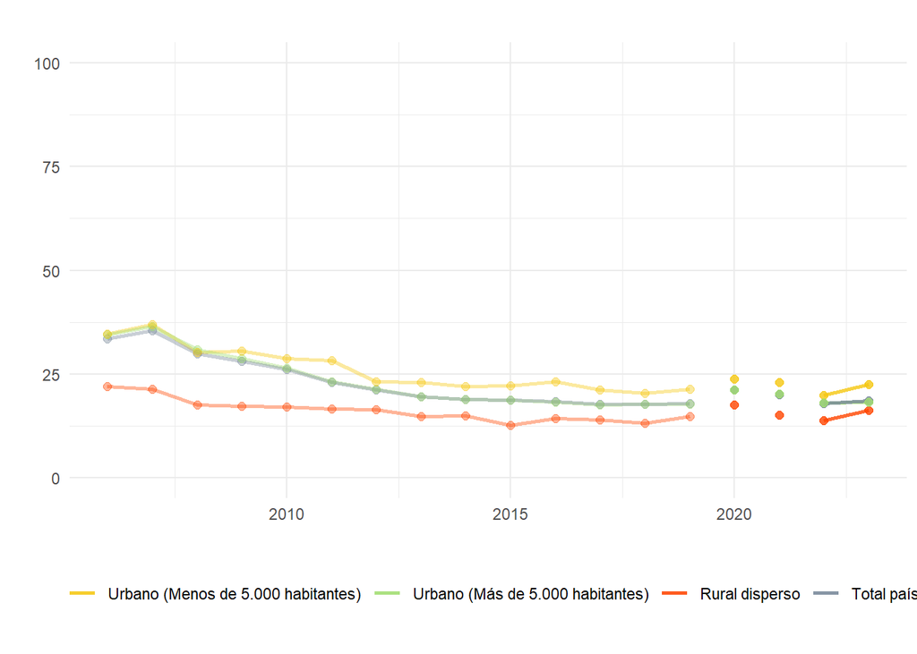

#### Tabla

|  | NOMINDICADOR | PAÍS | UNIDAD_GEOGRÁFICA | ANIO | VALOR |
| --- | --- | --- | --- | --- | --- |
| 46 | PORCENTAJE DE OCUPADOS QUE PERCIBEN UN INGRESO POR DEBAJO DE LA LÍNEA DE POBREZA | URUGUAY | RURAL DISPERSO | 2006 | 22 |
| 1 | PORCENTAJE DE OCUPADOS QUE PERCIBEN UN INGRESO POR DEBAJO DE LA LÍNEA DE POBREZA | URUGUAY | TOTAL PAÍS | 2006 | 33.5 |
| 16 | PORCENTAJE DE OCUPADOS QUE PERCIBEN UN INGRESO POR DEBAJO DE LA LÍNEA DE POBREZA | URUGUAY | URBANO (MÁS DE 5.000 HABITANTES) | 2006 | 34.4 |
| 31 | PORCENTAJE DE OCUPADOS QUE PERCIBEN UN INGRESO POR DEBAJO DE LA LÍNEA DE POBREZA | URUGUAY | URBANO (MENOS DE 5.000 HABITANTES) | 2006 | 34.7 |
| 47 | PORCENTAJE DE OCUPADOS QUE PERCIBEN UN INGRESO POR DEBAJO DE LA LÍNEA DE POBREZA | URUGUAY | RURAL DISPERSO | 2007 | 21.3 |
| 2 | PORCENTAJE DE OCUPADOS QUE PERCIBEN UN INGRESO POR DEBAJO DE LA LÍNEA DE POBREZA | URUGUAY | TOTAL PAÍS | 2007 | 35.4 |
| 17 | PORCENTAJE DE OCUPADOS QUE PERCIBEN UN INGRESO POR DEBAJO DE LA LÍNEA DE POBREZA | URUGUAY | URBANO (MÁS DE 5.000 HABITANTES) | 2007 | 36.4 |
| 32 | PORCENTAJE DE OCUPADOS QUE PERCIBEN UN INGRESO POR DEBAJO DE LA LÍNEA DE POBREZA | URUGUAY | URBANO (MENOS DE 5.000 HABITANTES) | 2007 | 36.9 |
| 48 | PORCENTAJE DE OCUPADOS QUE PERCIBEN UN INGRESO POR DEBAJO DE LA LÍNEA DE POBREZA | URUGUAY | RURAL DISPERSO | 2008 | 17.6 |
| 3 | PORCENTAJE DE OCUPADOS QUE PERCIBEN UN INGRESO POR DEBAJO DE LA LÍNEA DE POBREZA | URUGUAY | TOTAL PAÍS | 2008 | 29.9 |

[output cut: 62 more lines]

#### Ficha Técnica

> **Definición:** Porcentaje de ocupados que perciben ingresos laborales por debajo de la línea de pobreza unipersonal (metodología 2006, INE).

> **Forma de cálculo:** (Cantidad de personas con ingresos laborales por debajo de la LP/ Cantidad total de personas ocupadas)*100

> **Advertencia:** Desde marzo de 2020 hasta junio de 2021 se interrumpió el relevamiento presencial y se aplicó de manera telefónica un cuestionario restringido con el objetivo de continuar publicando los indicadores de ingresos y mercado de trabajo. En ese período la encuesta pasó a ser de paneles rotativos elegidos al azar a partir de los casos respondentes del año anterior.  
> En julio de 2021 el INE retomó la realización de encuestas presenciales, pero introdujo un cambio metodológico, ya que la ECH pasa a ser una encuesta de panel rotativo con periodicidad mensual compuesta por seis paneles o grupos de rotación, cada uno de los cuales es una muestra representativa de la población. Con esta nueva metodología, cada hogar seleccionado participa durante seis meses de la ECH.  
> Para 2020, este indicador se construye con la encuesta presencial hasta marzo de 2020 y, posteriormente, con la encuesta telefónica panel. Para 2021, este indicador se calcula a partir de la encuesta telefónica del primer semestre de 2021 y el formulario presencial de modalidad panel del segundo semestre de 2021. En el segundo semestre, el quintil de ingresos y la condición de pobreza del hogar corresponde a los ingresos declarados durante la implantación del panel en la encuesta presencial. A partir del año 2022, el indicador se calcula con base en la encuesta presencial.

#### Código en R

```r
### Estimación de valores 2022 ###

# Para sintaxix de años anteriores consultar:
# https://osf.io/dyzg8/files/osfstorage#

# ~~~~~~~~~~~~~~~~~~~~~~~~~~~~~~~~~~~~~~~~~~~~~~~~~~~~~~~~~~~~~~~~~~~~~~~~~~~ #

### Carga de paquetes ###

# Instalar si es necesario:
#install.packages("rio")
#install.packages("srvyr")
#install.packages("tidyverse")

library(rio)
library(srvyr)
library(tidyverse)


# ~~~~~~~~~~~~~~~~~~~~~~~~~~~~~~~~~~~~~~~~~~~~~~~~~~~~~~~~~~~~~~~~~~~~~~~~~~~ #

### Descarga bases ECH 2022 (INE) de repositorio UMAD-FCS ###

download.file(
  url = "https://osf.io/download/rehz2/",
  destfile = "Base anual 2022.Rdata"
)


# ~~~~~~~~~~~~~~~~~~~~~~~~~~~~~~~~~~~~~~~~~~~~~~~~~~~~~~~~~~~~~~~~~~~~~~~~~~~ #

### Carga de bases ###

base            <- rio::import("Bases/Base anual 2022.csv")

# ~~~~~~~~~~~~~~~~~~~~~~~~~~~~~~~~~~~~~~~~~~~~~~~~~~~~~~~~~~~~~~~~~~~~~~~~~~~ #


## Generación de nuevas variables ###

base <- base %>% dplyr::mutate(bc_ipc_tot = case_when(
  mes == 1 ~  0.310804203,
  mes == 2 ~  0.305354401,
  mes == 3 ~  0.300928439,
  mes == 4 ~  0.297635795,
  mes == 5 ~  0.296181029,
  mes == 6 ~  0.294810362,
  mes == 7 ~  0.293094596,
  mes == 8 ~  0.290852868,
  mes == 9 ~  0.288466429,
  mes == 10 ~ 0.286063926,
  mes == 11 ~ 0.28546134,
  mes == 12 ~ 0.286262936))


# Ocupados

base <- base %>% dplyr::mutate(ocup = ifelse(POBPCOAC==2, 1, 0))


# Salario en ocupación principal

base <- base %>% dplyr::mutate(horamen = f85 * 4.3)
base <- base %>% dplyr::mutate(yhora = PT2/horamen)
base <- base %>% dplyr::mutate(yhoradef = case_when(f85>0 ~ yhora*bc_ipc_tot,
                                                    f85==0 ~ 0))


# Línea de pobreza individual

base <- base %>% dplyr::mutate(regionlp = case_when(region_4 == 1 ~ 1,
                                                    region_4 == 2 | region_4 == 3 ~ 2,
                                                    region_4 == 4 ~ 3))


base <- base %>% dplyr::mutate(grupolp = case_when(regionlp == 1 & mes == 1  ~ 1,
                                                   regionlp == 1 & mes == 2  ~ 2,
                                                   regionlp == 1 & mes == 3  ~ 3,
                                                   regionlp == 1 & mes == 4  ~ 4,
                                                   regionlp == 1 & mes == 5  ~ 5,
                                                   regionlp == 1 & mes == 6  ~ 6,
                                                   regionlp == 1 & mes == 7  ~ 7,
                                                   regionlp == 1 & mes == 8  ~ 8,
                                                   regionlp == 1 & mes == 9  ~ 9,
                                                   regionlp == 1 & mes == 10 ~ 10,
                                                   regionlp == 1 & mes == 11 ~ 11,
                                                   regionlp == 1 & mes == 12 ~ 12,
                                                   regionlp == 2 & mes == 1  ~ 13,
                                                   regionlp == 2 & mes == 2  ~ 14,
                                                   regionlp == 2 & mes == 3  ~ 15,
                                                   regionlp == 2 & mes == 4  ~ 16,
                                                   regionlp == 2 & mes == 5  ~ 17,
                                                   regionlp == 2 & mes == 6  ~ 18,
                                                   regionlp == 2 & mes == 7  ~ 19,
                                                   regionlp == 2 & mes == 8  ~ 20,
                                                   regionlp == 2 & mes == 9  ~ 21,
                                                   regionlp == 2 & mes == 10 ~ 22,
                                                   regionlp == 2 & mes == 11 ~ 23,
                                                   regionlp == 2 & mes == 12 ~ 24,
                                                   regionlp == 3 & mes == 1  ~ 25,
                                                   regionlp == 3 & mes == 2  ~ 26,
                                                   regionlp == 3 & mes == 3  ~ 27,
                                                   regionlp == 3 & mes == 4  ~ 28,
                                                   regionlp == 3 & mes == 5  ~ 29,
                                                   regionlp == 3 & mes == 6  ~ 30,
                                                   regionlp == 3 & mes == 7  ~ 31,
                                                   regionlp == 3 & mes == 8  ~ 32,
                                                   regionlp == 3 & mes == 9  ~ 33,
                                                   regionlp == 3 & mes == 10 ~ 34,
                                                   regionlp == 3 & mes == 11 ~ 35,
                                                   regionlp == 3 & mes == 12 ~ 36))




base_unipersonales <- base %>%  filter(HT19==1)
base_unipersonales <- base_unipersonales[,c("grupolp", "lp")]
base_unipersonales <- base_unipersonales %>% dplyr::mutate(lp_unipersonales = lp)
base_unipersonales <- base_unipersonales[order(base_unipersonales$grupolp,
                                               base_unipersonales$lp_unipersonales,
                                               decreasing = TRUE), ]
base_unipersonales <- base_unipersonales %>% distinct(grupolp, .keep_all = TRUE)
base_unipersonales <- base_unipersonales[,c("grupolp","lp_unipersonales")]

base <- merge(base, base_unipersonales, by = "grupolp")





# Salario por debajo de línea de pobreza

base <- base %>% dplyr::mutate(salario_insuf   = ifelse(PT2 < lp_unipersonales, 1, 0))


# ~~~~~~~~~~~~~~~~~~~~~~~~~~~~~~~~~~~~~~~~~~~~~~~~~~~~~~~~~~~~~~~~~~~~~~~~~~~ #

### Información de muestreo ###

base_svy <- srvyr::as_survey_design(base, ids = ID, weights = w_ano)


# ~~~~~~~~~~~~~~~~~~~~~~~~~~~~~~~~~~~~~~~~~~~~~~~~~~~~~~~~~~~~~~~~~~~~~~~~~~~ #

### Estimación de indicadores ###


###  Porcentaje de personas ocupadas que perciben ingresos por debajo de la línea de pobreza

c_ano <- base_svy %>%
  srvyr::filter(ocup == 1 & (region_4 == 1 | region_4 == 2)) %>%
  srvyr::summarise(colname = srvyr::survey_mean(salario_insuf, na.rm=T))


# ~~~~~~~~~~~~~~~~~~~~~~~~~~~~~~~~~~~~~~~~~~~~~~~~~~~~~~~~~~~~~~~~~~~~~~~~~~~ #
```

Fuente: Unidad de Métodos y Acceso a Datos (UMAD), Facultad de Ciencias Sociales (FCS-UdelaR), a partir de la ECH del Instituto Nacional de Estadística (INE) compatibilizada por el Instituto de Economía (IECON) (2019) y ECH-INE (2020 a 2022)

Nota: La transparencia de colores representa cambios metodológicos en el relevamiento de las ECH. La línea se discontinúa en aquellos años en que ocurre el cambio (ver Ficha Técnica).

# **Transferencias**

## **Cobertura de las transferencias contributivas**

Los siguientes indicadores presentan el porcentaje de personas mayores de 65 años que perciben jubilaciones y el porcentaje de mayores de 65 años que perciben pensiones. Si bien ambos indicadores tienen una tendencia relativamente estable a lo largo del período, la proporción de mayores que perciben jubilación presenta una leve tendencia al aumento a partir del año 2007. Por su parte, la porporción que percibe pensiones presenta una leve tendencia al descenso a partir de 2010.

##### **Porcentaje de personas mayores de 65 años que perciben jubilación**

##### País urbano, 1992 - 2023

#### Gráfico

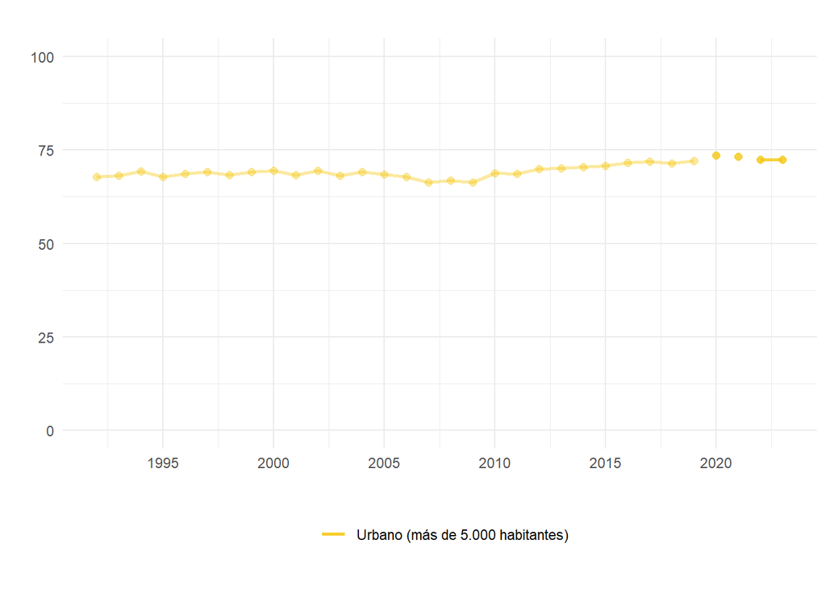

#### Tabla

|  | NOMINDICADOR | PAÍS | UNIDAD_GEOGRÁFICA | ANIO | VALOR |
| --- | --- | --- | --- | --- | --- |
| 1 | PORCENTAJE DE MAYORES DE 65 AÑOS QUE PERCIBEN JUBILACIÓN | URUGUAY | URBANO (MÁS DE 5.000 HABITANTES) | 1992 | 67.8 |
| 2 | PORCENTAJE DE MAYORES DE 65 AÑOS QUE PERCIBEN JUBILACIÓN | URUGUAY | URBANO (MÁS DE 5.000 HABITANTES) | 1993 | 68.2 |
| 3 | PORCENTAJE DE MAYORES DE 65 AÑOS QUE PERCIBEN JUBILACIÓN | URUGUAY | URBANO (MÁS DE 5.000 HABITANTES) | 1994 | 69.3 |
| 4 | PORCENTAJE DE MAYORES DE 65 AÑOS QUE PERCIBEN JUBILACIÓN | URUGUAY | URBANO (MÁS DE 5.000 HABITANTES) | 1995 | 67.9 |
| 5 | PORCENTAJE DE MAYORES DE 65 AÑOS QUE PERCIBEN JUBILACIÓN | URUGUAY | URBANO (MÁS DE 5.000 HABITANTES) | 1996 | 68.7 |
| 6 | PORCENTAJE DE MAYORES DE 65 AÑOS QUE PERCIBEN JUBILACIÓN | URUGUAY | URBANO (MÁS DE 5.000 HABITANTES) | 1997 | 69.1 |
| 7 | PORCENTAJE DE MAYORES DE 65 AÑOS QUE PERCIBEN JUBILACIÓN | URUGUAY | URBANO (MÁS DE 5.000 HABITANTES) | 1998 | 68.4 |
| 8 | PORCENTAJE DE MAYORES DE 65 AÑOS QUE PERCIBEN JUBILACIÓN | URUGUAY | URBANO (MÁS DE 5.000 HABITANTES) | 1999 | 69.2 |
| 9 | PORCENTAJE DE MAYORES DE 65 AÑOS QUE PERCIBEN JUBILACIÓN | URUGUAY | URBANO (MÁS DE 5.000 HABITANTES) | 2000 | 69.4 |
| 10 | PORCENTAJE DE MAYORES DE 65 AÑOS QUE PERCIBEN JUBILACIÓN | URUGUAY | URBANO (MÁS DE 5.000 HABITANTES) | 2001 | 68.4 |

[output cut: 22 more lines]

#### Ficha Técnica

> **Definición:** Porcentaje de mayores de 65 años que perciben jubilación

> **Forma de cálculo:** (Cantidad de personas mayores de 65 años que perciben jubilaciones / Cantidad de personas mayores de 65 años) *100

> **Advertencia:** Desde marzo de 2020 hasta junio de 2021 se interrumpió el relevamiento presencial y se aplicó de manera telefónica un cuestionario restringido con el objetivo de continuar publicando los indicadores de ingresos y mercado de trabajo. En ese período la encuesta pasó a ser de paneles rotativos elegidos al azar a partir de los casos respondentes del año anterior.  
> En julio de 2021 el INE retomó la realización de encuestas presenciales, pero introdujo un cambio metodológico, ya que la ECH pasa a ser una encuesta de panel rotativo con periodicidad mensual compuesta por seis paneles o grupos de rotación, cada uno de los cuales es una muestra representativa de la población. Con esta nueva metodología, cada hogar seleccionado participa durante seis meses de la ECH.  
> Para 2020, este indicador se construye con la encuesta presencial hasta marzo de 2020 y, posteriormente, con la encuesta telefónica panel. Para 2021, este indicador se calcula a partir de la encuesta telefónica del primer semestre de 2021 y el formulario presencial de modalidad panel del segundo semestre de 2021. En el segundo semestre, el quintil de ingresos y la condición de pobreza del hogar corresponde a los ingresos declarados durante la implantación del panel en la encuesta presencial. A partir del año 2022, el indicador se calcula con base en la encuesta presencial.

#### Código en R

```r
### Estimación de valores 2022 ###

# Para sintaxix de años anteriores consultar:
# https://osf.io/dyzg8/files/osfstorage#

# ~~~~~~~~~~~~~~~~~~~~~~~~~~~~~~~~~~~~~~~~~~~~~~~~~~~~~~~~~~~~~~~~~~~~~~~~~~~ #

### Carga de paquetes ###

# Instalar si es necesario:
#install.packages("rio")
#install.packages("srvyr")
#install.packages("tidyverse")

library(rio)
library(srvyr)
library(tidyverse)


# ~~~~~~~~~~~~~~~~~~~~~~~~~~~~~~~~~~~~~~~~~~~~~~~~~~~~~~~~~~~~~~~~~~~~~~~~~~~ #

### Descarga bases ECH 2022 (INE) de repositorio UMAD-FCS ###

download.file(
  url = "https://osf.io/download/rehz2/",
  destfile = "Base anual 2022.Rdata"
)


# ~~~~~~~~~~~~~~~~~~~~~~~~~~~~~~~~~~~~~~~~~~~~~~~~~~~~~~~~~~~~~~~~~~~~~~~~~~~ #

### Carga de bases ###

base            <- rio::import("Bases/Base anual 2022.csv")

# ~~~~~~~~~~~~~~~~~~~~~~~~~~~~~~~~~~~~~~~~~~~~~~~~~~~~~~~~~~~~~~~~~~~~~~~~~~~ #


## Generación de nuevas variables ###

# Percepción de jubilaciones

base <- base %>% dplyr::mutate(jub = ifelse(g148_1_1 > 0 |
                                            g148_1_2 > 0 |
                                            g148_1_3 > 0 |
                                            g148_1_5 > 0 |
                                            g148_1_6 > 0 |
                                            g148_1_7 > 0 |
                                            g148_1_8 > 0 |
                                            g148_1_9 > 0 |
                                            g148_1_10 > 0 |
                                            g148_1_11 > 0, 1, 0))


# ~~~~~~~~~~~~~~~~~~~~~~~~~~~~~~~~~~~~~~~~~~~~~~~~~~~~~~~~~~~~~~~~~~~~~~~~~~~ #

### Información de muestreo ###

base_svy <- srvyr::as_survey_design(base, ids = ID, weights = w_ano)


# ~~~~~~~~~~~~~~~~~~~~~~~~~~~~~~~~~~~~~~~~~~~~~~~~~~~~~~~~~~~~~~~~~~~~~~~~~~~ #

### Estimación de indicadores ###


###  Porcentaje de mayores de 65 años que perciben jubilación

c_ano <- base_svy %>%
  srvyr::filter(e27 >= 65  & (region_4 == 1 | region_4 == 2)) %>%
  srvyr::summarise(colname = srvyr::survey_mean(jub, na.rm=T))

# ~~~~~~~~~~~~~~~~~~~~~~~~~~~~~~~~~~~~~~~~~~~~~~~~~~~~~~~~~~~~~~~~~~~~~~~~~~~ #
```

Fuente: Unidad de Métodos y Acceso a Datos (UMAD), Facultad de Ciencias Sociales (FCS-UdelaR), a partir de la ECH del Instituto Nacional de Estadística (INE) compatibilizada por el Instituto de Economía (IECON) (2019) y ECH-INE (2020 a 2022)

Nota: La transparencia de colores representa cambios metodológicos en el relevamiento de las ECH. La línea se discontinúa en aquellos años en que ocurre el cambio (ver Ficha Técnica).

##### **Porcentaje de personas mayores de 65 años que perciben pensiones**

##### País urbano, 1992 - 2023

#### Gráfico

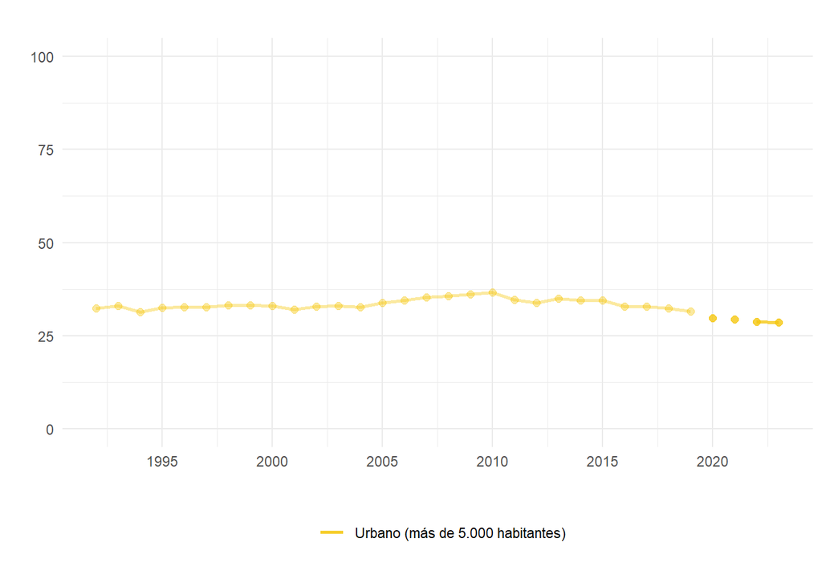

#### Tabla

|  | NOMINDICADOR | PAÍS | UNIDAD_GEOGRÁFICA | ANIO | VALOR |
| --- | --- | --- | --- | --- | --- |
| 1 | PORCENTAJE DE MAYORES DE 65 AÑOS QUE PERCIBEN PENSIÓN | URUGUAY | URBANO (MÁS DE 5.000 HABITANTES) | 1992 | 32.3 |
| 2 | PORCENTAJE DE MAYORES DE 65 AÑOS QUE PERCIBEN PENSIÓN | URUGUAY | URBANO (MÁS DE 5.000 HABITANTES) | 1993 | 33 |
| 3 | PORCENTAJE DE MAYORES DE 65 AÑOS QUE PERCIBEN PENSIÓN | URUGUAY | URBANO (MÁS DE 5.000 HABITANTES) | 1994 | 31.4 |
| 4 | PORCENTAJE DE MAYORES DE 65 AÑOS QUE PERCIBEN PENSIÓN | URUGUAY | URBANO (MÁS DE 5.000 HABITANTES) | 1995 | 32.5 |
| 5 | PORCENTAJE DE MAYORES DE 65 AÑOS QUE PERCIBEN PENSIÓN | URUGUAY | URBANO (MÁS DE 5.000 HABITANTES) | 1996 | 32.7 |
| 6 | PORCENTAJE DE MAYORES DE 65 AÑOS QUE PERCIBEN PENSIÓN | URUGUAY | URBANO (MÁS DE 5.000 HABITANTES) | 1997 | 32.7 |
| 7 | PORCENTAJE DE MAYORES DE 65 AÑOS QUE PERCIBEN PENSIÓN | URUGUAY | URBANO (MÁS DE 5.000 HABITANTES) | 1998 | 33.2 |
| 8 | PORCENTAJE DE MAYORES DE 65 AÑOS QUE PERCIBEN PENSIÓN | URUGUAY | URBANO (MÁS DE 5.000 HABITANTES) | 1999 | 33.2 |
| 9 | PORCENTAJE DE MAYORES DE 65 AÑOS QUE PERCIBEN PENSIÓN | URUGUAY | URBANO (MÁS DE 5.000 HABITANTES) | 2000 | 33 |
| 10 | PORCENTAJE DE MAYORES DE 65 AÑOS QUE PERCIBEN PENSIÓN | URUGUAY | URBANO (MÁS DE 5.000 HABITANTES) | 2001 | 32 |

[output cut: 22 more lines]

#### Ficha Técnica

> **Definición:** Porcentaje de mayores de 65 años que perciben pensiones

> **Forma de cálculo:** (Cantidad de personas mayores de 65 años que perciben pensiones/ Cantidad de personas mayores de 65 años) *100

> **Advertencia:** Desde marzo de 2020 hasta junio de 2021 se interrumpió el relevamiento presencial y se aplicó de manera telefónica un cuestionario restringido con el objetivo de continuar publicando los indicadores de ingresos y mercado de trabajo. En ese período la encuesta pasó a ser de paneles rotativos elegidos al azar a partir de los casos respondentes del año anterior.  
> En julio de 2021 el INE retomó la realización de encuestas presenciales, pero introdujo un cambio metodológico, ya que la ECH pasa a ser una encuesta de panel rotativo con periodicidad mensual compuesta por seis paneles o grupos de rotación, cada uno de los cuales es una muestra representativa de la población. Con esta nueva metodología, cada hogar seleccionado participa durante seis meses de la ECH.  
> Para 2020, este indicador se construye con la encuesta presencial hasta marzo de 2020 y, posteriormente, con la encuesta telefónica panel. Para 2021, este indicador se calcula a partir de la encuesta telefónica del primer semestre de 2021 y el formulario presencial de modalidad panel del segundo semestre de 2021. En el segundo semestre, el quintil de ingresos y la condición de pobreza del hogar corresponde a los ingresos declarados durante la implantación del panel en la encuesta presencial. A partir del año 2022, el indicador se calcula con base en la encuesta presencial.

#### Código en R

```r
### Estimación de valores 2022 ###

# Para sintaxix de años anteriores consultar:
# https://osf.io/dyzg8/files/osfstorage#

# ~~~~~~~~~~~~~~~~~~~~~~~~~~~~~~~~~~~~~~~~~~~~~~~~~~~~~~~~~~~~~~~~~~~~~~~~~~~ #

### Carga de paquetes ###

# Instalar si es necesario:
#install.packages("rio")
#install.packages("srvyr")
#install.packages("tidyverse")

library(rio)
library(srvyr)
library(tidyverse)


# ~~~~~~~~~~~~~~~~~~~~~~~~~~~~~~~~~~~~~~~~~~~~~~~~~~~~~~~~~~~~~~~~~~~~~~~~~~~ #

### Descarga bases ECH 2022 (INE) de repositorio UMAD-FCS ###

download.file(
  url = "https://osf.io/download/rehz2/",
  destfile = "Base anual 2022.Rdata"
)

# ~~~~~~~~~~~~~~~~~~~~~~~~~~~~~~~~~~~~~~~~~~~~~~~~~~~~~~~~~~~~~~~~~~~~~~~~~~~ #

### Carga de bases ###

base            <- rio::import("Bases/Base anual 2022.csv")

# ~~~~~~~~~~~~~~~~~~~~~~~~~~~~~~~~~~~~~~~~~~~~~~~~~~~~~~~~~~~~~~~~~~~~~~~~~~~ #


## Generación de nuevas variables ###

# Percepción de pensiones

base <- base %>% dplyr::mutate(pens = ifelse(g148_2_1 > 0 |
                                             g148_2_2 > 0 |
                                             g148_2_3 > 0 |
                                             g148_2_5 > 0 |
                                             g148_2_6 > 0 |
                                             g148_2_7 > 0 |
                                             g148_2_8 > 0 |
                                             g148_2_9 > 0 |
                                             g148_2_10 > 0 |
                                             g148_2_11 > 0, 1, 0))


# ~~~~~~~~~~~~~~~~~~~~~~~~~~~~~~~~~~~~~~~~~~~~~~~~~~~~~~~~~~~~~~~~~~~~~~~~~~~ #

### Información de muestreo ###

base_svy <- srvyr::as_survey_design(base, ids = ID, weights = w_ano)


# ~~~~~~~~~~~~~~~~~~~~~~~~~~~~~~~~~~~~~~~~~~~~~~~~~~~~~~~~~~~~~~~~~~~~~~~~~~~ #

### Estimación de indicadores ###


###  Porcentaje de mayores de 65 años que perciben pensión

c_ano <- base_svy %>%
  srvyr::filter(e27 >= 65 & (region_4 == 1 | region_4 == 2)) %>%
  srvyr::summarise(colname = srvyr::survey_mean(pens, na.rm=T))


# ~~~~~~~~~~~~~~~~~~~~~~~~~~~~~~~~~~~~~~~~~~~~~~~~~~~~~~~~~~~~~~~~~~~~~~~~~~~ #
```

Fuente: Unidad de Métodos y Acceso a Datos (UMAD), Facultad de Ciencias Sociales (FCS-UdelaR), a partir de la ECH del Instituto Nacional de Estadística (INE) compatibilizada por el Instituto de Economía (IECON) (2019) y ECH-INE (2020 a 2022)

Nota: La transparencia de colores representa cambios metodológicos en el relevamiento de las ECH. La línea se discontinúa en aquellos años en que ocurre el cambio (ver Ficha Técnica).

## **Suficiencia de las transferencias contributivas**

Los siguientes gráficos son indicativos de la suficiencia de ingresos jubilatorios. El primer inicador muestra el porcentaje de jubilados cuyos ingresos mensuales se encuentran por debajo del salario mínimo nacional. El segundo indicador da cuenta de la poroporción de esta población cuyo ingreso se encuentra por debajo de la línea de pobreza individual (definida para la población que reside en hogares unipersonales). El primer indicador presenta un aumento durante el período, mientras el segundo un importante descenso.

##### **Porcentaje de personas que perciben jubilaciones por debajo del salario mínimo nacional**

##### Total país, 2006 - 2023

#### Gráfico

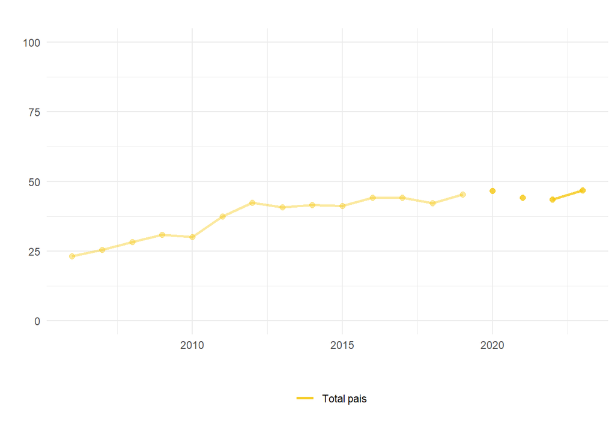

#### Tabla

|  | NOMINDICADOR | PAÍS | UNIDAD_GEOGRÁFICA | ANIO | VALOR |
| --- | --- | --- | --- | --- | --- |
| 1 | PORCENTAJE PERSONAS QUE PERCIBEN JUBILACIONES POR DEBAJO DEL SALARIO MÍNIMO NACIONAL | URUGUAY | TOTAL PAÍS | 2006 | 23.2 |
| 2 | PORCENTAJE PERSONAS QUE PERCIBEN JUBILACIONES POR DEBAJO DEL SALARIO MÍNIMO NACIONAL | URUGUAY | TOTAL PAÍS | 2007 | 25.5 |
| 3 | PORCENTAJE PERSONAS QUE PERCIBEN JUBILACIONES POR DEBAJO DEL SALARIO MÍNIMO NACIONAL | URUGUAY | TOTAL PAÍS | 2008 | 28.2 |
| 4 | PORCENTAJE PERSONAS QUE PERCIBEN JUBILACIONES POR DEBAJO DEL SALARIO MÍNIMO NACIONAL | URUGUAY | TOTAL PAÍS | 2009 | 30.8 |
| 5 | PORCENTAJE PERSONAS QUE PERCIBEN JUBILACIONES POR DEBAJO DEL SALARIO MÍNIMO NACIONAL | URUGUAY | TOTAL PAÍS | 2010 | 30 |
| 6 | PORCENTAJE PERSONAS QUE PERCIBEN JUBILACIONES POR DEBAJO DEL SALARIO MÍNIMO NACIONAL | URUGUAY | TOTAL PAÍS | 2011 | 37.4 |
| 7 | PORCENTAJE PERSONAS QUE PERCIBEN JUBILACIONES POR DEBAJO DEL SALARIO MÍNIMO NACIONAL | URUGUAY | TOTAL PAÍS | 2012 | 42.4 |
| 8 | PORCENTAJE PERSONAS QUE PERCIBEN JUBILACIONES POR DEBAJO DEL SALARIO MÍNIMO NACIONAL | URUGUAY | TOTAL PAÍS | 2013 | 40.7 |
| 9 | PORCENTAJE PERSONAS QUE PERCIBEN JUBILACIONES POR DEBAJO DEL SALARIO MÍNIMO NACIONAL | URUGUAY | TOTAL PAÍS | 2014 | 41.6 |
| 10 | PORCENTAJE PERSONAS QUE PERCIBEN JUBILACIONES POR DEBAJO DEL SALARIO MÍNIMO NACIONAL | URUGUAY | TOTAL PAÍS | 2015 | 41.2 |

[output cut: 8 more lines]

#### Ficha Técnica

> **Definición:** Porcentaje de personas que preciben jubilaciones por debajo del salario mínimo nacional

> **Forma de cálculo:** (Cantidad de personas mayores de 65 años que perciben jubilaciones por debajo del SMN / Cantidad de personas mayores de 65 años que perciben jubilaciones) *100

> **Advertencia:** Desde marzo de 2020 hasta junio de 2021 se interrumpió el relevamiento presencial y se aplicó de manera telefónica un cuestionario restringido con el objetivo de continuar publicando los indicadores de ingresos y mercado de trabajo. En ese período la encuesta pasó a ser de paneles rotativos elegidos al azar a partir de los casos respondentes del año anterior.  
> En julio de 2021 el INE retomó la realización de encuestas presenciales, pero introdujo un cambio metodológico, ya que la ECH pasa a ser una encuesta de panel rotativo con periodicidad mensual compuesta por seis paneles o grupos de rotación, cada uno de los cuales es una muestra representativa de la población. Con esta nueva metodología, cada hogar seleccionado participa durante seis meses de la ECH.  
> Para 2020, este indicador se construye con la encuesta presencial hasta marzo de 2020 y, posteriormente, con la encuesta telefónica panel. Para 2021, este indicador se calcula a partir de la encuesta telefónica del primer semestre de 2021 y el formulario presencial de modalidad panel del segundo semestre de 2021. En el segundo semestre, el quintil de ingresos y la condición de pobreza del hogar corresponde a los ingresos declarados durante la implantación del panel en la encuesta presencial. A partir del año 2022, el indicador se calcula con base en la encuesta presencial.

#### Código en R

```r
### Estimación de valores 2022 ###

# Para sintaxix de años anteriores consultar:
# https://osf.io/dyzg8/files/osfstorage#

# ~~~~~~~~~~~~~~~~~~~~~~~~~~~~~~~~~~~~~~~~~~~~~~~~~~~~~~~~~~~~~~~~~~~~~~~~~~~ #

### Carga de paquetes ###

# Instalar si es necesario:
#install.packages("rio")
#install.packages("srvyr")
#install.packages("tidyverse")

library(rio)
library(srvyr)
library(tidyverse)


# ~~~~~~~~~~~~~~~~~~~~~~~~~~~~~~~~~~~~~~~~~~~~~~~~~~~~~~~~~~~~~~~~~~~~~~~~~~~ #

### Descarga bases ECH 2022 (INE) de repositorio UMAD-FCS ###

download.file(
  url = "https://osf.io/download/rehz2/",
  destfile = "Base anual 2022.Rdata"
)


# ~~~~~~~~~~~~~~~~~~~~~~~~~~~~~~~~~~~~~~~~~~~~~~~~~~~~~~~~~~~~~~~~~~~~~~~~~~~ #

### Carga de bases ###

base            <- rio::import("Bases/Base anual 2022.csv")

# ~~~~~~~~~~~~~~~~~~~~~~~~~~~~~~~~~~~~~~~~~~~~~~~~~~~~~~~~~~~~~~~~~~~~~~~~~~~ #


## Generación de nuevas variables ###

smn <- 19364
smn_h = smn/200

# Percepción de jubilaciones

base <- base %>% dplyr::mutate(jub = ifelse(g148_1_1 > 0 |
                                            g148_1_2 > 0 |
                                            g148_1_3 > 0 |
                                            g148_1_5 > 0 |
                                            g148_1_6 > 0 |
                                            g148_1_7 > 0 |
                                            g148_1_8 > 0 |
                                            g148_1_9 > 0 |
                                            g148_1_10 > 0 |
                                            g148_1_11 > 0, 1, 0))

# Ingresos por jubilaciones

base <- base %>% dplyr::mutate(y_jub = g148_1_1 +
                                 g148_1_2 +
                                 g148_1_3 +
                                 g148_1_5 +
                                 g148_1_6 +
                                 g148_1_7 +
                                 g148_1_8 +
                                 g148_1_9 +
                                 g148_1_12 +
                                 g148_1_10 +
                                 g148_1_11)

# Ingresos por jubilaciones por debajo del salario mínimo nacional

base <- base %>% dplyr::mutate(jub_insuf_smn = ifelse(y_jub < smn, 1, 0))


# ~~~~~~~~~~~~~~~~~~~~~~~~~~~~~~~~~~~~~~~~~~~~~~~~~~~~~~~~~~~~~~~~~~~~~~~~~~~ #

### Información de muestreo ###

base_svy <- srvyr::as_survey_design(base, ids = ID, weights = w_ano)


# ~~~~~~~~~~~~~~~~~~~~~~~~~~~~~~~~~~~~~~~~~~~~~~~~~~~~~~~~~~~~~~~~~~~~~~~~~~~ #

### Estimación de indicadores ###


###  Porcentaje de personas que perciben jubilaciones por debajo del SMN

c_ano <- base_svy %>%
  srvyr::filter(jub == 1) %>%
  srvyr::summarise(colname = srvyr::survey_mean(jub_insuf_smn, na.rm=T))


# ~~~~~~~~~~~~~~~~~~~~~~~~~~~~~~~~~~~~~~~~~~~~~~~~~~~~~~~~~~~~~~~~~~~~~~~~~~~ #
```

Fuente: Unidad de Métodos y Acceso a Datos (UMAD), Facultad de Ciencias Sociales (FCS-UdelaR), a partir de la ECH del Instituto Nacional de Estadística (INE) compatibilizada por el Instituto de Economía (IECON) (2019) y ECH-INE (2020 a 2022)

Nota: La transparencia de colores representa cambios metodológicos en el relevamiento de las ECH. La línea se discontinúa en aquellos años en que ocurre el cambio (ver Ficha Técnica).

##### **Porcentaje de personas que perciben jubilaciones por debajo de la línea de pobreza**

##### Total país, 2006 - 2023

#### Gráfico

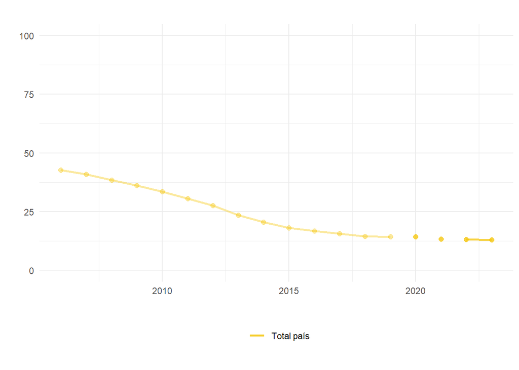

#### Tabla

|  | NOMINDICADOR | PAÍS | UNIDAD_GEOGRÁFICA | ANIO | VALOR |
| --- | --- | --- | --- | --- | --- |
| 1 | PORCENTAJE PERSONAS QUE PERCIBEN JUBILACIONES POR DEBAJO DE LA LÍNEA DE POBREZA | URUGUAY | TOTAL PAÍS | 2006 | 42.7 |
| 2 | PORCENTAJE PERSONAS QUE PERCIBEN JUBILACIONES POR DEBAJO DE LA LÍNEA DE POBREZA | URUGUAY | TOTAL PAÍS | 2007 | 40.9 |
| 3 | PORCENTAJE PERSONAS QUE PERCIBEN JUBILACIONES POR DEBAJO DE LA LÍNEA DE POBREZA | URUGUAY | TOTAL PAÍS | 2008 | 38.4 |
| 4 | PORCENTAJE PERSONAS QUE PERCIBEN JUBILACIONES POR DEBAJO DE LA LÍNEA DE POBREZA | URUGUAY | TOTAL PAÍS | 2009 | 36.1 |
| 5 | PORCENTAJE PERSONAS QUE PERCIBEN JUBILACIONES POR DEBAJO DE LA LÍNEA DE POBREZA | URUGUAY | TOTAL PAÍS | 2010 | 33.5 |
| 6 | PORCENTAJE PERSONAS QUE PERCIBEN JUBILACIONES POR DEBAJO DE LA LÍNEA DE POBREZA | URUGUAY | TOTAL PAÍS | 2011 | 30.6 |
| 7 | PORCENTAJE PERSONAS QUE PERCIBEN JUBILACIONES POR DEBAJO DE LA LÍNEA DE POBREZA | URUGUAY | TOTAL PAÍS | 2012 | 27.5 |
| 8 | PORCENTAJE PERSONAS QUE PERCIBEN JUBILACIONES POR DEBAJO DE LA LÍNEA DE POBREZA | URUGUAY | TOTAL PAÍS | 2013 | 23.5 |
| 9 | PORCENTAJE PERSONAS QUE PERCIBEN JUBILACIONES POR DEBAJO DE LA LÍNEA DE POBREZA | URUGUAY | TOTAL PAÍS | 2014 | 20.5 |
| 10 | PORCENTAJE PERSONAS QUE PERCIBEN JUBILACIONES POR DEBAJO DE LA LÍNEA DE POBREZA | URUGUAY | TOTAL PAÍS | 2015 | 18.1 |

[output cut: 8 more lines]

#### Ficha Técnica

> **Definición:** Porcentaje de personas que preciben jubilaciones por debajo de la línea de pobreza unipersonal (metodología 2006, INE).

> **Forma de cálculo:** (Cantidad de personas mayores de 65 años que perciben jubilaciones por debajo de la LP / Cantidad de personas mayores de 65 años que perciben jubilaciones) *100

> **Advertencia:** Desde marzo de 2020 hasta junio de 2021 se interrumpió el relevamiento presencial y se aplicó de manera telefónica un cuestionario restringido con el objetivo de continuar publicando los indicadores de ingresos y mercado de trabajo. En ese período la encuesta pasó a ser de paneles rotativos elegidos al azar a partir de los casos respondentes del año anterior.  
> En julio de 2021 el INE retomó la realización de encuestas presenciales, pero introdujo un cambio metodológico, ya que la ECH pasa a ser una encuesta de panel rotativo con periodicidad mensual compuesta por seis paneles o grupos de rotación, cada uno de los cuales es una muestra representativa de la población. Con esta nueva metodología, cada hogar seleccionado participa durante seis meses de la ECH.  
> Para 2020, este indicador se construye con la encuesta presencial hasta marzo de 2020 y, posteriormente, con la encuesta telefónica panel. Para 2021, este indicador se calcula a partir de la encuesta telefónica del primer semestre de 2021 y el formulario presencial de modalidad panel del segundo semestre de 2021. En el segundo semestre, el quintil de ingresos y la condición de pobreza del hogar corresponde a los ingresos declarados durante la implantación del panel en la encuesta presencial. A partir del año 2022, el indicador se calcula con base en la encuesta presencial.

#### Código en R

```r
### Estimación de valores 2022 ###

# Para sintaxix de años anteriores consultar:
# https://osf.io/dyzg8/files/osfstorage#

# ~~~~~~~~~~~~~~~~~~~~~~~~~~~~~~~~~~~~~~~~~~~~~~~~~~~~~~~~~~~~~~~~~~~~~~~~~~~ #

### Carga de paquetes ###

# Instalar si es necesario:
#install.packages("rio")
#install.packages("srvyr")
#install.packages("tidyverse")

library(rio)
library(srvyr)
library(tidyverse)


# ~~~~~~~~~~~~~~~~~~~~~~~~~~~~~~~~~~~~~~~~~~~~~~~~~~~~~~~~~~~~~~~~~~~~~~~~~~~ #

### Descarga bases ECH 2022 (INE) de repositorio UMAD-FCS ###

download.file(
  url = "https://osf.io/download/rehz2/",
  destfile = "Base anual 2022.Rdata"
)

# ~~~~~~~~~~~~~~~~~~~~~~~~~~~~~~~~~~~~~~~~~~~~~~~~~~~~~~~~~~~~~~~~~~~~~~~~~~~ #

### Carga de bases ###

base            <- rio::import("Bases/Base anual 2022.csv")

# ~~~~~~~~~~~~~~~~~~~~~~~~~~~~~~~~~~~~~~~~~~~~~~~~~~~~~~~~~~~~~~~~~~~~~~~~~~~ #


## Generación de nuevas variables ###


# Línea de pobreza individual

base <- base %>% dplyr::mutate(regionlp = case_when(region_4 == 1 ~ 1,
                                                    region_4 == 2 | region_4 == 3 ~ 2,
                                                    region_4 == 4 ~ 3))


base <- base %>% dplyr::mutate(grupolp = case_when(regionlp == 1 & mes == 1  ~ 1,
                                                   regionlp == 1 & mes == 2  ~ 2,
                                                   regionlp == 1 & mes == 3  ~ 3,
                                                   regionlp == 1 & mes == 4  ~ 4,
                                                   regionlp == 1 & mes == 5  ~ 5,
                                                   regionlp == 1 & mes == 6  ~ 6,
                                                   regionlp == 1 & mes == 7  ~ 7,
                                                   regionlp == 1 & mes == 8  ~ 8,
                                                   regionlp == 1 & mes == 9  ~ 9,
                                                   regionlp == 1 & mes == 10 ~ 10,
                                                   regionlp == 1 & mes == 11 ~ 11,
                                                   regionlp == 1 & mes == 12 ~ 12,
                                                   regionlp == 2 & mes == 1  ~ 13,
                                                   regionlp == 2 & mes == 2  ~ 14,
                                                   regionlp == 2 & mes == 3  ~ 15,
                                                   regionlp == 2 & mes == 4  ~ 16,
                                                   regionlp == 2 & mes == 5  ~ 17,
                                                   regionlp == 2 & mes == 6  ~ 18,
                                                   regionlp == 2 & mes == 7  ~ 19,
                                                   regionlp == 2 & mes == 8  ~ 20,
                                                   regionlp == 2 & mes == 9  ~ 21,
                                                   regionlp == 2 & mes == 10 ~ 22,
                                                   regionlp == 2 & mes == 11 ~ 23,
                                                   regionlp == 2 & mes == 12 ~ 24,
                                                   regionlp == 3 & mes == 1  ~ 25,
                                                   regionlp == 3 & mes == 2  ~ 26,
                                                   regionlp == 3 & mes == 3  ~ 27,
                                                   regionlp == 3 & mes == 4  ~ 28,
                                                   regionlp == 3 & mes == 5  ~ 29,
                                                   regionlp == 3 & mes == 6  ~ 30,
                                                   regionlp == 3 & mes == 7  ~ 31,
                                                   regionlp == 3 & mes == 8  ~ 32,
                                                   regionlp == 3 & mes == 9  ~ 33,
                                                   regionlp == 3 & mes == 10 ~ 34,
                                                   regionlp == 3 & mes == 11 ~ 35,
                                                   regionlp == 3 & mes == 12 ~ 36))




base_unipersonales <- base %>%  filter(HT19==1)
base_unipersonales <- base_unipersonales[,c("grupolp", "lp")]
base_unipersonales <- base_unipersonales %>% dplyr::mutate(lp_unipersonales = lp)
base_unipersonales <- base_unipersonales[order(base_unipersonales$grupolp,
                                               base_unipersonales$lp_unipersonales,
                                               decreasing = TRUE), ]
base_unipersonales <- base_unipersonales %>% distinct(grupolp, .keep_all = TRUE)
base_unipersonales <- base_unipersonales[,c("grupolp","lp_unipersonales")]

base <- merge(base, base_unipersonales, by = "grupolp")


# Percepción de jubilaciones

base <- base %>% dplyr::mutate(jub = ifelse(g148_1_1 > 0 |
                                            g148_1_2 > 0 |
                                            g148_1_3 > 0 |
                                            g148_1_5 > 0 |
                                            g148_1_6 > 0 |
                                            g148_1_7 > 0 |
                                            g148_1_8 > 0 |
                                            g148_1_9 > 0 |
                                            g148_1_10 > 0 |
                                            g148_1_11 > 0, 1, 0))

# Ingresos por jubilaciones

base <- base %>% dplyr::mutate(y_jub = g148_1_1 +
                                 g148_1_2 +
                                 g148_1_3 +
                                 g148_1_5 +
                                 g148_1_6 +
                                 g148_1_7 +
                                 g148_1_8 +
                                 g148_1_9 +
                                 g148_1_12 +
                                 g148_1_10 +
                                 g148_1_11)


# Ingresos por jubilaciones por debajo de la línea de pobreza

base <- base %>% dplyr::mutate(jub_insuf = ifelse(y_jub < lp_unipersonales, 1, 0))


# ~~~~~~~~~~~~~~~~~~~~~~~~~~~~~~~~~~~~~~~~~~~~~~~~~~~~~~~~~~~~~~~~~~~~~~~~~~~ #

### Información de muestreo ###

base_svy <- srvyr::as_survey_design(base, ids = ID, weights = w_ano)


# ~~~~~~~~~~~~~~~~~~~~~~~~~~~~~~~~~~~~~~~~~~~~~~~~~~~~~~~~~~~~~~~~~~~~~~~~~~~ #

### Estimación de indicadores ###


###  Porcentaje de personas que perciben jubilaciones por debajo de la línea de pobreza

c_ano <- base_svy %>%
  srvyr::filter(jub == 1) %>%
  srvyr::summarise(colname = srvyr::survey_mean(jub_insuf, na.rm=T))


# ~~~~~~~~~~~~~~~~~~~~~~~~~~~~~~~~~~~~~~~~~~~~~~~~~~~~~~~~~~~~~~~~~~~~~~~~~~~ #
```

Fuente: Unidad de Métodos y Acceso a Datos (UMAD), Facultad de Ciencias Sociales (FCS-UdelaR), a partir de la ECH del Instituto Nacional de Estadística (INE) compatibilizada por el Instituto de Economía (IECON) (2019) y ECH-INE (2020 a 2022)

Nota: La transparencia de colores representa cambios metodológicos en el relevamiento de las ECH. La línea se discontinúa en aquellos años en que ocurre el cambio (ver Ficha Técnica).

## **Cobertura de las transferencias no contributivas**

##### **Porcentaje de hogares que perciben asignaciones familiares (Plan de equidad)**

##### Total país, 2009 - 2023

#### Gráfico

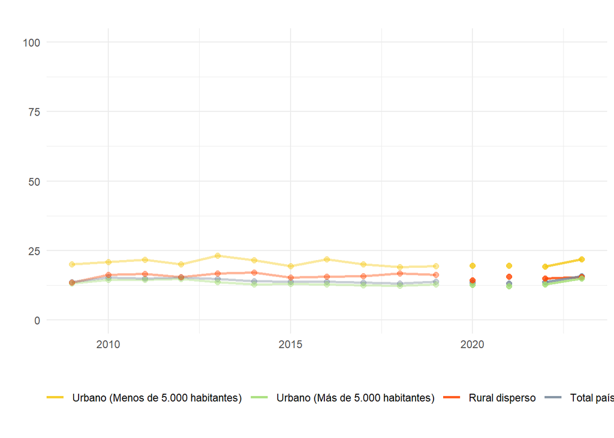

#### Tabla

|  | NOMINDICADOR | PAÍS | UNIDAD_GEOGRÁFICA | ANIO | VALOR |
| --- | --- | --- | --- | --- | --- |
| 37 | PORCENTAJE DE HOGARES QUE PERCIBEN ASIGNACIONES FAMILIARES (SOLO PLAN DE EQUIDAD) | URUGUAY | RURAL DISPERSO | 2009 | 13.4 |
| 1 | PORCENTAJE DE HOGARES QUE PERCIBEN ASIGNACIONES FAMILIARES (SOLO PLAN DE EQUIDAD) | URUGUAY | TOTAL PAÍS | 2009 | 13.6 |
| 13 | PORCENTAJE DE HOGARES QUE PERCIBEN ASIGNACIONES FAMILIARES (SOLO PLAN DE EQUIDAD) | URUGUAY | URBANO (MÁS DE 5.000 HABITANTES) | 2009 | 13.1 |
| 25 | PORCENTAJE DE HOGARES QUE PERCIBEN ASIGNACIONES FAMILIARES (SOLO PLAN DE EQUIDAD) | URUGUAY | URBANO (MENOS DE 5.000 HABITANTES) | 2009 | 20 |
| 38 | PORCENTAJE DE HOGARES QUE PERCIBEN ASIGNACIONES FAMILIARES (SOLO PLAN DE EQUIDAD) | URUGUAY | RURAL DISPERSO | 2010 | 16.3 |
| 2 | PORCENTAJE DE HOGARES QUE PERCIBEN ASIGNACIONES FAMILIARES (SOLO PLAN DE EQUIDAD) | URUGUAY | TOTAL PAÍS | 2010 | 15.3 |
| 14 | PORCENTAJE DE HOGARES QUE PERCIBEN ASIGNACIONES FAMILIARES (SOLO PLAN DE EQUIDAD) | URUGUAY | URBANO (MÁS DE 5.000 HABITANTES) | 2010 | 14.4 |
| 26 | PORCENTAJE DE HOGARES QUE PERCIBEN ASIGNACIONES FAMILIARES (SOLO PLAN DE EQUIDAD) | URUGUAY | URBANO (MENOS DE 5.000 HABITANTES) | 2010 | 20.9 |
| 39 | PORCENTAJE DE HOGARES QUE PERCIBEN ASIGNACIONES FAMILIARES (SOLO PLAN DE EQUIDAD) | URUGUAY | RURAL DISPERSO | 2011 | 16.5 |
| 3 | PORCENTAJE DE HOGARES QUE PERCIBEN ASIGNACIONES FAMILIARES (SOLO PLAN DE EQUIDAD) | URUGUAY | TOTAL PAÍS | 2011 | 14.9 |

[output cut: 50 more lines]

#### Ficha Técnica

> **Definición:** Porcentaje de hogares que perciben asignaciones familiares (solo Plan de Equidad)

> **Forma de cálculo:** (Cantidad de hogares que perciben asignaciones familiares del plan de equidad / Cantidad de hogares) *100

> **Advertencia:** Desde marzo de 2020 hasta junio de 2021 se interrumpió el relevamiento presencial y se aplicó de manera telefónica un cuestionario restringido con el objetivo de continuar publicando los indicadores de ingresos y mercado de trabajo. En ese período la encuesta pasó a ser de paneles rotativos elegidos al azar a partir de los casos respondentes del año anterior.  
> En julio de 2021 el INE retomó la realización de encuestas presenciales, pero introdujo un cambio metodológico, ya que la ECH pasa a ser una encuesta de panel rotativo con periodicidad mensual compuesta por seis paneles o grupos de rotación, cada uno de los cuales es una muestra representativa de la población. Con esta nueva metodología, cada hogar seleccionado participa durante seis meses de la ECH.  
> Para 2020, este indicador se construye con la encuesta presencial hasta marzo de 2020 y, posteriormente, con la encuesta telefónica panel. Para 2021, este indicador se calcula a partir de la encuesta telefónica del primer semestre de 2021 y el formulario presencial de modalidad panel del segundo semestre de 2021. En el segundo semestre, el quintil de ingresos y la condición de pobreza del hogar corresponde a los ingresos declarados durante la implantación del panel en la encuesta presencial. A partir del año 2022, el indicador se calcula con base en la encuesta presencial.

#### Código en R

```r
### Estimación de valores 2022 ###

# Para sintaxix de años anteriores consultar:
# https://osf.io/dyzg8/files/osfstorage#

# ~~~~~~~~~~~~~~~~~~~~~~~~~~~~~~~~~~~~~~~~~~~~~~~~~~~~~~~~~~~~~~~~~~~~~~~~~~~ #

### Carga de paquetes ###

# Instalar si es necesario:
#install.packages("rio")
#install.packages("srvyr")
#install.packages("tidyverse")

library(rio)
library(srvyr)
library(tidyverse)


# ~~~~~~~~~~~~~~~~~~~~~~~~~~~~~~~~~~~~~~~~~~~~~~~~~~~~~~~~~~~~~~~~~~~~~~~~~~~ #

### Descarga bases ECH 2022 (INE) de repositorio UMAD-FCS ###

download.file(
  url = "https://osf.io/download/rehz2/",
  destfile = "Base anual 2022.Rdata"
)


# ~~~~~~~~~~~~~~~~~~~~~~~~~~~~~~~~~~~~~~~~~~~~~~~~~~~~~~~~~~~~~~~~~~~~~~~~~~~ #

### Carga de bases ###

base            <- rio::import("Bases/Base anual 2022.csv")

# ~~~~~~~~~~~~~~~~~~~~~~~~~~~~~~~~~~~~~~~~~~~~~~~~~~~~~~~~~~~~~~~~~~~~~~~~~~~ #


## Generación de nuevas variables ###


# Captación AFAM

base <- base %>% dplyr::mutate(afam_pe = ifelse((g152 == 1 & f73 != 2 & f92 !=2 ) | (g150 == 1 & (POBPCOAC %in% c(1, 3, 4, 6, 7, 8, 11) | (POBPCOAC == 2 & f82 != 1 & f96 != 1))), 1, 0),
                               afam_cont = ifelse(g150 == 1 & afam_pe == 0, 1, 0),
                               afam_total = ifelse(afam_pe == 1 | afam_cont == 1, 1, 0))

base_afam <- base[,c("ID","afam_pe", "afam_cont", "afam_total")]
base_afam <- base_afam %>% dplyr::mutate(h_afam_pe = afam_pe,
                                         h_afam_cont = afam_cont,
                                         h_afam_total = afam_total)

base_afam_1 <- base_afam[order(base_afam$ID, base_afam$h_afam_pe, decreasing = TRUE), ]
base_afam_2 <- base_afam[order(base_afam$ID, base_afam$h_afam_cont, decreasing = TRUE), ]
base_afam_3 <- base_afam[order(base_afam$ID, base_afam$h_afam_total, decreasing = TRUE), ]

base_afam_1 <- base_afam_1 %>% distinct(ID, .keep_all = TRUE)
base_afam_2 <- base_afam_2 %>% distinct(ID, .keep_all = TRUE)
base_afam_3 <- base_afam_3 %>% distinct(ID, .keep_all = TRUE)

base_afam_1 <- base_afam_1[,c("ID","h_afam_pe")]
base_afam_2 <- base_afam_2[,c("ID","h_afam_cont")]
base_afam_3 <- base_afam_3[,c("ID","h_afam_total")]

base <- merge(base, base_afam_1, by = "ID")
base <- merge(base, base_afam_2, by = "ID")
base <- merge(base, base_afam_3, by = "ID")


# ~~~~~~~~~~~~~~~~~~~~~~~~~~~~~~~~~~~~~~~~~~~~~~~~~~~~~~~~~~~~~~~~~~~~~~~~~~~ #

### Bases a nivel hogar ###

base_h <- base %>% distinct(ID, .keep_all = TRUE)

# ~~~~~~~~~~~~~~~~~~~~~~~~~~~~~~~~~~~~~~~~~~~~~~~~~~~~~~~~~~~~~~~~~~~~~~~~~~~ #

### Información de muestreo ###

base_h_svy <- srvyr::as_survey_design(base_h, ids = ID, weights = w_ano)


# ~~~~~~~~~~~~~~~~~~~~~~~~~~~~~~~~~~~~~~~~~~~~~~~~~~~~~~~~~~~~~~~~~~~~~~~~~~~ #

### Estimación de indicadores ###


###  Porcentaje de hogares que perciben AFAM (Solo Plan de Equidad)


c_ano <- base_h_svy %>%
  srvyr::summarise(colname = srvyr::survey_mean(h_afam_pe, na.rm=T))


# ~~~~~~~~~~~~~~~~~~~~~~~~~~~~~~~~~~~~~~~~~~~~~~~~~~~~~~~~~~~~~~~~~~~~~~~~~~~ #
```

Fuente: Unidad de Métodos y Acceso a Datos (UMAD), Facultad de Ciencias Sociales (FCS-UdelaR), a partir de la ECH del Instituto Nacional de Estadística (INE) compatibilizada por el Instituto de Economía (IECON) (2019) y ECH-INE (2020 a 2022)

Nota: La transparencia de colores representa cambios metodológicos en el relevamiento de las ECH. La línea se discontinúa en aquellos años en que ocurre el cambio (ver Ficha Técnica).

##### **Porcentaje de hogares que perciben Tarjeta Uruguay Social**

##### Total país, 2015 - 2023

#### Gráfico

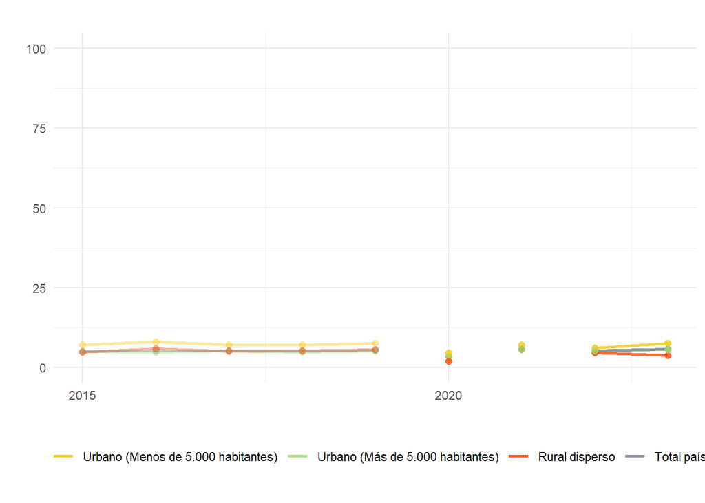

#### Tabla

|  | NOMINDICADOR | PAÍS | UNIDAD_GEOGRÁFICA | ANIO | VALOR |
| --- | --- | --- | --- | --- | --- |
| 19 | PORCENTAJE DE HOGARES QUE PERCIBEN TARJETA URUGUAY SOCIAL | URUGUAY | RURAL DISPERSO | 2015 | 4.7 |
| 1 | PORCENTAJE DE HOGARES QUE PERCIBEN TARJETA URUGUAY SOCIAL | URUGUAY | TOTAL PAÍS | 2015 | 5.1 |
| 7 | PORCENTAJE DE HOGARES QUE PERCIBEN TARJETA URUGUAY SOCIAL | URUGUAY | URBANO (MÁS DE 5.000 HABITANTES) | 2015 | 4.9 |
| 13 | PORCENTAJE DE HOGARES QUE PERCIBEN TARJETA URUGUAY SOCIAL | URUGUAY | URBANO (MENOS DE 5.000 HABITANTES) | 2015 | 7 |
| 20 | PORCENTAJE DE HOGARES QUE PERCIBEN TARJETA URUGUAY SOCIAL | URUGUAY | RURAL DISPERSO | 2016 | 5.9 |
| 2 | PORCENTAJE DE HOGARES QUE PERCIBEN TARJETA URUGUAY SOCIAL | URUGUAY | TOTAL PAÍS | 2016 | 5.2 |
| 8 | PORCENTAJE DE HOGARES QUE PERCIBEN TARJETA URUGUAY SOCIAL | URUGUAY | URBANO (MÁS DE 5.000 HABITANTES) | 2016 | 4.8 |
| 14 | PORCENTAJE DE HOGARES QUE PERCIBEN TARJETA URUGUAY SOCIAL | URUGUAY | URBANO (MENOS DE 5.000 HABITANTES) | 2016 | 8 |
| 21 | PORCENTAJE DE HOGARES QUE PERCIBEN TARJETA URUGUAY SOCIAL | URUGUAY | RURAL DISPERSO | 2017 | 5.1 |
| 3 | PORCENTAJE DE HOGARES QUE PERCIBEN TARJETA URUGUAY SOCIAL | URUGUAY | TOTAL PAÍS | 2017 | 5.3 |

[output cut: 26 more lines]

#### Ficha Técnica

> **Definición:** Porcentaje de hogares que perciben Tarjetas Uruguay Social

> **Forma de cálculo:** (Cantidad de hogares que perciben Tarjeta Uruguay Social / Cantidad de hogares) *100

> **Advertencia:** Desde marzo de 2020 hasta junio de 2021 se interrumpió el relevamiento presencial y se aplicó de manera telefónica un cuestionario restringido con el objetivo de continuar publicando los indicadores de ingresos y mercado de trabajo. En ese período la encuesta pasó a ser de paneles rotativos elegidos al azar a partir de los casos respondentes del año anterior.  
> En julio de 2021 el INE retomó la realización de encuestas presenciales, pero introdujo un cambio metodológico, ya que la ECH pasa a ser una encuesta de panel rotativo con periodicidad mensual compuesta por seis paneles o grupos de rotación, cada uno de los cuales es una muestra representativa de la población. Con esta nueva metodología, cada hogar seleccionado participa durante seis meses de la ECH.  
> Para 2020, este indicador se construye con la encuesta presencial hasta marzo de 2020 y, posteriormente, con la encuesta telefónica panel. Para 2021, este indicador se calcula a partir de la encuesta telefónica del primer semestre de 2021 y el formulario presencial de modalidad panel del segundo semestre de 2021. En el segundo semestre, el quintil de ingresos y la condición de pobreza del hogar corresponde a los ingresos declarados durante la implantación del panel en la encuesta presencial. A partir del año 2022, el indicador se calcula con base en la encuesta presencial.

#### Código en R

```r
### Estimación de valores 2022 ###

# Para sintaxix de años anteriores consultar:
# https://osf.io/dyzg8/files/osfstorage#

# ~~~~~~~~~~~~~~~~~~~~~~~~~~~~~~~~~~~~~~~~~~~~~~~~~~~~~~~~~~~~~~~~~~~~~~~~~~~ #

### Carga de paquetes ###

# Instalar si es necesario:
#install.packages("rio")
#install.packages("srvyr")
#install.packages("tidyverse")

library(rio)
library(srvyr)
library(tidyverse)


# ~~~~~~~~~~~~~~~~~~~~~~~~~~~~~~~~~~~~~~~~~~~~~~~~~~~~~~~~~~~~~~~~~~~~~~~~~~~ #

### Descarga bases ECH 2022 (INE) de repositorio UMAD-FCS ###

download.file(
  url = "https://osf.io/download/rehz2/",
  destfile = "Base anual 2022.Rdata"
)


# ~~~~~~~~~~~~~~~~~~~~~~~~~~~~~~~~~~~~~~~~~~~~~~~~~~~~~~~~~~~~~~~~~~~~~~~~~~~ #

### Carga de bases ###

base            <- rio::import("Bases/Base anual 2022.csv")

# ~~~~~~~~~~~~~~~~~~~~~~~~~~~~~~~~~~~~~~~~~~~~~~~~~~~~~~~~~~~~~~~~~~~~~~~~~~~ #


## Generación de nuevas variables ###



#  Captación TUS


base <- base %>% dplyr::mutate(tus = ifelse(e560==1, 1, 0))

base_tus <- base[,c("ID","tus")]
base_tus <- base_tus %>% dplyr::mutate(h_tus = tus)
base_tus <- base_tus[order(base_tus$ID, base_tus$h_tus, decreasing = TRUE), ]
base_tus <- base_tus %>% distinct(ID, .keep_all = TRUE)
base_tus <- base_tus[,c("ID","h_tus")]
base <- merge(base, base_tus, by = "ID")


# ~~~~~~~~~~~~~~~~~~~~~~~~~~~~~~~~~~~~~~~~~~~~~~~~~~~~~~~~~~~~~~~~~~~~~~~~~~~ #

### Bases a nivel hogar ###

base_h <- base %>% distinct(ID, .keep_all = TRUE)


# ~~~~~~~~~~~~~~~~~~~~~~~~~~~~~~~~~~~~~~~~~~~~~~~~~~~~~~~~~~~~~~~~~~~~~~~~~~~ #

### Información de muestreo ###

base_h_svy <- srvyr::as_survey_design(base_h, ids = ID, weights = w_ano)



# ~~~~~~~~~~~~~~~~~~~~~~~~~~~~~~~~~~~~~~~~~~~~~~~~~~~~~~~~~~~~~~~~~~~~~~~~~~~ #

### Estimación de indicadores ###


###  Porcentaje de hogares que perciben TUS


c_ano <- base_h_svy %>%
  srvyr::summarise(colname = srvyr::survey_mean(h_tus, na.rm=T))



# ~~~~~~~~~~~~~~~~~~~~~~~~~~~~~~~~~~~~~~~~~~~~~~~~~~~~~~~~~~~~~~~~~~~~~~~~~~~ #
```

Fuente: Unidad de Métodos y Acceso a Datos (UMAD), Facultad de Ciencias Sociales (FCS-UdelaR), a partir de la ECH del Instituto Nacional de Estadística (INE) compatibilizada por el Instituto de Economía (IECON) (2019) y ECH-INE (2020 a 2022)

Nota: La transparencia de colores representa cambios metodológicos en el relevamiento de las ECH. La línea se discontinúa en aquellos años en que ocurre el cambio (ver Ficha Técnica).

# **Referencias**

## **Sistema de consultas**

Acceda a nuestro sistema de consultas personalizado de indicadores de empleo, salarios y transferencias en el siguiente [link](https://bancodedatos-fcs.shinyapps.io/app-Empleo-Salarios-Transferencias/).

## **Contacto**

Si tiene consultas, sugerencias, comentarios o encontró algún error en este documento, le agradecemos que se contacte con nosotros/as.

**Contacto: umad@cienciassociales.edu.uy**